# allAssignments

### Portfolio assignment 3

15 min: Perform a univariate analysis on all the categorical data of the penguins dataset. Commit the notebook to your portfolio when you're finished.

Import seaborn

```python
import seaborn as sns
```

Set penguins

```python
penguins = sns.load_dataset("penguins")
```

Get the types of the columns

```python
penguins.dtypes
```

```
species               object
island                object
bill_length_mm       float64
bill_depth_mm        float64
flipper_length_mm    float64
body_mass_g          float64
sex                   object
dtype: object
```

Univariate analysis on all the categorical data so the species, island and sex can be analized.

#### Species:

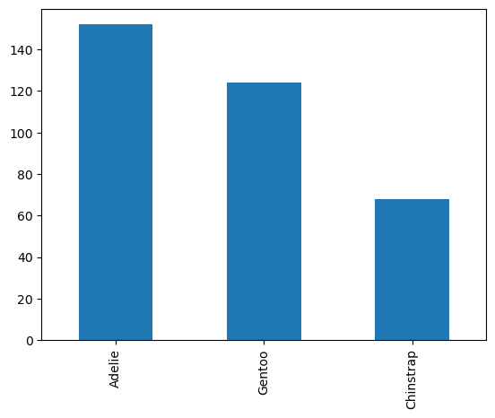

```python
penguins['species'].value_counts().plot(kind='bar')
```

#### Island:

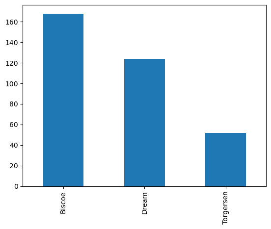

```python
penguins['island'].value_counts().plot(kind='bar')
```

#### Sex:

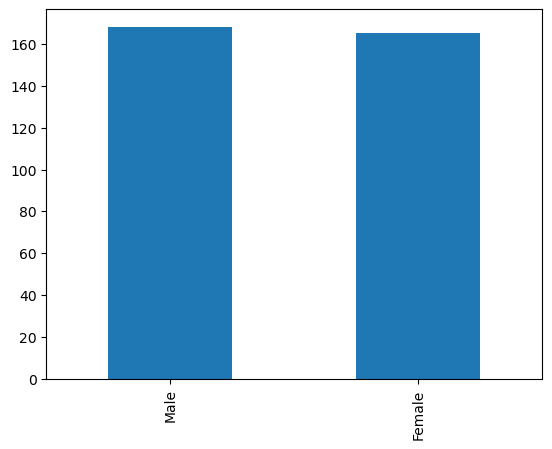

```python
penguins['sex'].value_counts().plot(kind='bar')
```

### Portfolio assignment 5

20 min:

- Download lifeExpectancyAtBirth.csv from Brightspace ([original source](https://www.kaggle.com/utkarshxy/who-worldhealth-statistics-2020-complete?select=lifeExpectancyAtBirth.csv)).
- Move the file to the same folder as the Notebook that you will be working in.
- Load the dataset in your Notebook with the following code: lifeExpectancy = pd.read_csv('lifeExpectancyAtBirth.csv', sep=',')
- Look at the dataset with the .head() function.
- Filter the dataframe: We only want the life expectancy data about 2019 and 'Both sexes'
- Use this dataframe to perform a univariate analysis on the life expectancy in 2019.
- Which five countries have the highest life expectancy? Which five the lowest?

Commit the notebook and dataset to your portfolio when you're finished.

Import pd

```python
import pandas as pd
```

Read the excel file

```python
lifeExpectancy = pd.read_csv('lifeExpectancyAtBirth.csv', sep=',')
```

Head of the set

```python
lifeExpectancy.head()
```

|  | Location | Period | Indicator | Dim1 | First Tooltip |
| --- | --- | --- | --- | --- | --- |
| 0 | Afghanistan | 2019 | Life expectancy at birth (years) | Both sexes | 63.21 |
| 1 | Afghanistan | 2019 | Life expectancy at birth (years) | Male | 63.29 |
| 2 | Afghanistan | 2019 | Life expectancy at birth (years) | Female | 63.16 |
| 3 | Afghanistan | 2015 | Life expectancy at birth (years) | Both sexes | 61.65 |
| 4 | Afghanistan | 2015 | Life expectancy at birth (years) | Male | 61.04 |

Get columns:

```python
lifeExpectancy.columns
```

```
Index(['Location', 'Period', 'Indicator', 'Dim1', 'First Tooltip'], dtype='object')
```

Data where period is 2019:

```python
lifeExpectancy[lifeExpectancy['Period'] == 2019]
```

|  | Location | Period | Indicator | Dim1 | First Tooltip |
| --- | --- | --- | --- | --- | --- |
| 0 | Afghanistan | 2019 | Life expectancy at birth (years) | Both sexes | 63.21 |
| 1 | Afghanistan | 2019 | Life expectancy at birth (years) | Male | 63.29 |
| 2 | Afghanistan | 2019 | Life expectancy at birth (years) | Female | 63.16 |
| 12 | Albania | 2019 | Life expectancy at birth (years) | Both sexes | 78.00 |
| 13 | Albania | 2019 | Life expectancy at birth (years) | Male | 76.25 |
| ... | ... | ... | ... | ... | ... |
| 2174 | Zambia | 2019 | Life expectancy at birth (years) | Male | 59.54 |
| 2175 | Zambia | 2019 | Life expectancy at birth (years) | Female | 65.37 |
| 2185 | Zimbabwe | 2019 | Life expectancy at birth (years) | Both sexes | 60.68 |
| 2186 | Zimbabwe | 2019 | Life expectancy at birth (years) | Male | 57.51 |
| 2187 | Zimbabwe | 2019 | Life expectancy at birth (years) | Female | 63.61 |

549 rows × 5 columns

```python
lifeExpectancy[lifeExpectancy['Dim1'] == 'Both sexes']
```

|  | Location | Period | Indicator | Dim1 | First Tooltip |
| --- | --- | --- | --- | --- | --- |
| 0 | Afghanistan | 2019 | Life expectancy at birth (years) | Both sexes | 63.21 |
| 3 | Afghanistan | 2015 | Life expectancy at birth (years) | Both sexes | 61.65 |
| 6 | Afghanistan | 2010 | Life expectancy at birth (years) | Both sexes | 59.94 |
| 9 | Afghanistan | 2000 | Life expectancy at birth (years) | Both sexes | 54.99 |
| 12 | Albania | 2019 | Life expectancy at birth (years) | Both sexes | 78.00 |
| ... | ... | ... | ... | ... | ... |
| 2182 | Zambia | 2000 | Life expectancy at birth (years) | Both sexes | 44.46 |
| 2185 | Zimbabwe | 2019 | Life expectancy at birth (years) | Both sexes | 60.68 |
| 2188 | Zimbabwe | 2015 | Life expectancy at birth (years) | Both sexes | 58.48 |
| 2191 | Zimbabwe | 2010 | Life expectancy at birth (years) | Both sexes | 51.49 |
| 2194 | Zimbabwe | 2000 | Life expectancy at birth (years) | Both sexes | 46.57 |

733 rows × 5 columns

Combine the filters:

```python
lifeExpectancy[(lifeExpectancy['Dim1'] == 'Both sexes') & (lifeExpectancy['Period'] == 2019)]
```

|  | Location | Period | Indicator | Dim1 | First Tooltip |
| --- | --- | --- | --- | --- | --- |
| 0 | Afghanistan | 2019 | Life expectancy at birth (years) | Both sexes | 63.21 |
| 12 | Albania | 2019 | Life expectancy at birth (years) | Both sexes | 78.00 |
| 24 | Algeria | 2019 | Life expectancy at birth (years) | Both sexes | 77.13 |
| 36 | Angola | 2019 | Life expectancy at birth (years) | Both sexes | 63.06 |
| 48 | Antigua and Barbuda | 2019 | Life expectancy at birth (years) | Both sexes | 76.45 |
| ... | ... | ... | ... | ... | ... |
| 2137 | Venezuela (Bolivarian Republic of) | 2019 | Life expectancy at birth (years) | Both sexes | 73.95 |
| 2149 | Viet Nam | 2019 | Life expectancy at birth (years) | Both sexes | 73.74 |
| 2161 | Yemen | 2019 | Life expectancy at birth (years) | Both sexes | 66.63 |
| 2173 | Zambia | 2019 | Life expectancy at birth (years) | Both sexes | 62.45 |
| 2185 | Zimbabwe | 2019 | Life expectancy at birth (years) | Both sexes | 60.68 |

183 rows × 5 columns

Save variable with filter:

```python
filteredVariable = lifeExpectancy[(lifeExpectancy['Dim1'] == 'Both sexes') & (lifeExpectancy['Period'] == 2019)]
```

Plot data:

#### Location:

```python
filteredVariable['Location'].unique()
```

```
array(['Afghanistan', 'Albania', 'Algeria', 'Angola',
       'Antigua and Barbuda', 'Argentina', 'Armenia', 'Australia',
       'Austria', 'Azerbaijan', 'Bahamas', 'Bahrain', 'Bangladesh',
       'Barbados', 'Belarus', 'Belgium', 'Belize', 'Benin', 'Bhutan',
       'Bolivia (Plurinational State of)', 'Bosnia and Herzegovina',
       'Botswana', 'Brazil', 'Brunei Darussalam', 'Bulgaria',
       'Burkina Faso', 'Burundi', 'Cabo Verde', 'Cambodia', 'Cameroon',
       'Canada', 'Central African Republic', 'Chad', 'Chile', 'China',
       'Colombia', 'Comoros', 'Congo', 'Costa Rica', 'Côte d’Ivoire',
       'Croatia', 'Cuba', 'Cyprus', 'Czechia',
       "Democratic People's Republic of Korea",
       'Democratic Republic of the Congo', 'Denmark', 'Djibouti',
       'Dominican Republic', 'Ecuador', 'Egypt', 'El Salvador',
       'Equatorial Guinea', 'Eritrea', 'Estonia', 'Eswatini', 'Ethiopia',
       'Fiji', 'Finland', 'France', 'Gabon', 'Gambia', 'Georgia',
       'Germany', 'Ghana', 'Greece', 'Grenada', 'Guatemala', 'Guinea',
       'Guinea-Bissau', 'Guyana', 'Haiti', 'Honduras', 'Hungary',
       'Iceland', 'India', 'Indonesia', 'Iran (Islamic Republic of)',
       'Iraq', 'Ireland', 'Israel', 'Italy', 'Jamaica', 'Japan', 'Jordan',
       'Kazakhstan', 'Kenya', 'Kiribati', 'Kuwait', 'Kyrgyzstan',
       "Lao People's Democratic Republic", 'Latvia', 'Lebanon', 'Lesotho',
       'Liberia', 'Libya', 'Lithuania', 'Luxembourg', 'Madagascar',
       'Malawi', 'Malaysia', 'Maldives', 'Mali', 'Malta', 'Mauritania',
       'Mauritius', 'Mexico', 'Micronesia (Federated States of)',
       'Mongolia', 'Montenegro', 'Morocco', 'Mozambique', 'Myanmar',
       'Namibia', 'Nepal', 'Netherlands', 'New Zealand', 'Nicaragua',
       'Niger', 'Nigeria', 'Norway', 'Oman', 'Pakistan', 'Panama',
       'Papua New Guinea', 'Paraguay', 'Peru', 'Philippines', 'Poland',
       'Portugal', 'Qatar', 'Republic of Korea', 'Republic of Moldova',
       'The former Yugoslav Republic of Macedonia', 'Romania',
       'Russian Federation', 'Rwanda', 'Saint Lucia',
       'Saint Vincent and the Grenadines', 'Samoa',
       'Sao Tome and Principe', 'Saudi Arabia', 'Senegal', 'Serbia',
       'Seychelles', 'Sierra Leone', 'Singapore', 'Slovakia', 'Slovenia',
       'Solomon Islands', 'Somalia', 'South Africa', 'South Sudan',
       'Spain', 'Sri Lanka', 'Sudan', 'Suriname', 'Sweden', 'Switzerland',
       'Syrian Arab Republic', 'Tajikistan', 'Thailand', 'Timor-Leste',
       'Togo', 'Tonga', 'Trinidad and Tobago', 'Tunisia', 'Turkey',
       'Turkmenistan', 'Uganda', 'Ukraine', 'United Arab Emirates',
       'United Kingdom of Great Britain and Northern Ireland',
       'United Republic of Tanzania', 'United States of America',
       'Uruguay', 'Uzbekistan', 'Vanuatu',
       'Venezuela (Bolivarian Republic of)', 'Viet Nam', 'Yemen',
       'Zambia', 'Zimbabwe'], dtype=object)
```

#### Period:

```python
filteredVariable['Period'].unique()
```

```
array([2019], dtype=int64)
```

#### Indicator:

```python
filteredVariable['Indicator'].unique()
```

```
array(['Life expectancy at birth (years)'], dtype=object)
```

#### Dim1

```python
filteredVariable['Dim1'].unique()
```

```
array(['Both sexes'], dtype=object)
```

#### First Tooltip:

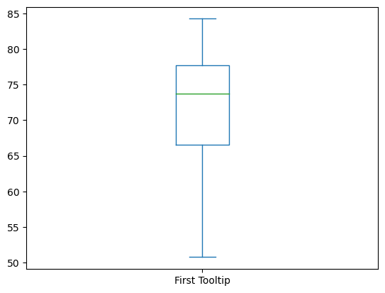

```python
filteredVariable['First Tooltip'].plot(kind='box')
```

#### De vijf landen met de laagste levensverwachting:

```python
filteredVariable.sort_values('First Tooltip').nsmallest(5, "First Tooltip")
```

|  | Location | Period | Indicator | Dim1 | First Tooltip |
| --- | --- | --- | --- | --- | --- |
| 1117 | Lesotho | 2019 | Life expectancy at birth (years) | Both sexes | 50.75 |
| 373 | Central African Republic | 2019 | Life expectancy at birth (years) | Both sexes | 53.10 |
| 1801 | Somalia | 2019 | Life expectancy at birth (years) | Both sexes | 56.47 |
| 661 | Eswatini | 2019 | Life expectancy at birth (years) | Both sexes | 57.73 |
| 1333 | Mozambique | 2019 | Life expectancy at birth (years) | Both sexes | 58.14 |

```python
filteredVariable.sort_values('First Tooltip').nlargest(5, "First Tooltip")
```

|  | Location | Period | Indicator | Dim1 | First Tooltip |
| --- | --- | --- | --- | --- | --- |
| 997 | Japan | 2019 | Life expectancy at birth (years) | Both sexes | 84.26 |
| 1897 | Switzerland | 2019 | Life expectancy at birth (years) | Both sexes | 83.45 |
| 1573 | Republic of Korea | 2019 | Life expectancy at birth (years) | Both sexes | 83.30 |
| 1837 | Spain | 2019 | Life expectancy at birth (years) | Both sexes | 83.22 |
| 1753 | Singapore | 2019 | Life expectancy at birth (years) | Both sexes | 83.22 |

### Portfolio assignment 6

60 min: Perform a univariate analysis on at least 2 columns with categorical data and on at least 2 columns with numerical data in the dataset that you chose in portfolio assignment 4. Commit the Notebook to your portfolio when you're finished.

```python
import pandas as pd
playerStats = pd.read_csv('playerStats.csv', sep=',')
```

```python
playerStats.head()
```

|  | League | Team | Season | KEY | Player | Position | Appearances | Goals | Started | Started As A Sub | ... | Minutes per Yellow Cards | Sent Off | Straight Red Card | Two Yellow Cards | Red - First Half | Red - Second Half | Red - Home | Red - Away | Red - Minutes Played | Minutes per Red Cards |
| --- | --- | --- | --- | --- | --- | --- | --- | --- | --- | --- | --- | --- | --- | --- | --- | --- | --- | --- | --- | --- | --- |
| 0 | Premier League | Chelsea | 2016/17 | Premier League\|Chelsea\|2016/17 | NaN | NaN | NaN | 83.0 | NaN | NaN | ... | NaN | NaN | NaN | NaN | NaN | NaN | NaN | NaN | NaN | NaN |
| 1 | Premier League | Chelsea | 2016/17 | Premier League\|Chelsea\|2016/17 | Cesar Azpilicueta | Defender | 38.0 | 1.0 | 38.0 | 0.0 | ... | 855 | NaN | NaN | NaN | NaN | NaN | NaN | NaN | NaN | NaN |
| 2 | Premier League | Chelsea | 2016/17 | Premier League\|Chelsea\|2016/17 | Gary Cahill | Defender | 37.0 | 6.0 | 36.0 | 2.0 | ... | 659.2 | NaN | NaN | NaN | NaN | NaN | NaN | NaN | NaN | NaN |
| 3 | Premier League | Chelsea | 2016/17 | Premier League\|Chelsea\|2016/17 | Eden Hazard | Midfielder | 36.0 | 16.0 | 36.0 | 0.0 | ... | 1002 | NaN | NaN | NaN | NaN | NaN | NaN | NaN | NaN | NaN |
| 4 | Premier League | Chelsea | 2016/17 | Premier League\|Chelsea\|2016/17 | Thibaut Courtois | Goalkeeper | 36.0 | 0.0 | 36.0 | 0.0 | ... | 3240 | NaN | NaN | NaN | NaN | NaN | NaN | NaN | NaN | NaN |

5 rows × 57 columns

#### Only select players and not the teams

```python
playerStatsAllLeagues = playerStats[(playerStats['Player'].notnull())]
```

#### Team:

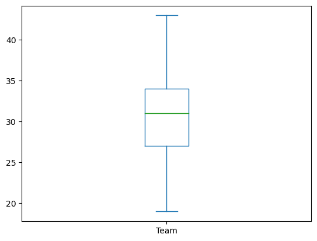

```python
playerStatsAllLeagues['Team'].value_counts().plot(kind='box')
```

Door middel van deze boxplot is te zien wat de verdeling is van het aantal spelers van de clubs

#### Position:

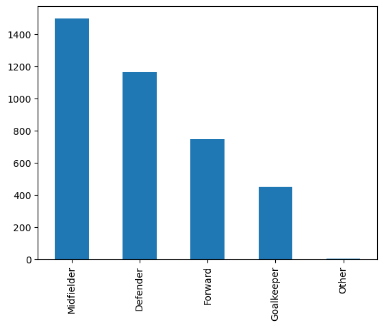

```python
playerStatsAllLeagues['Position'].value_counts().plot(kind='bar')
```

Door gebruik te maken van een barplot is te zien hoeveel spelers op welke positie spelen.

#### Appearances:

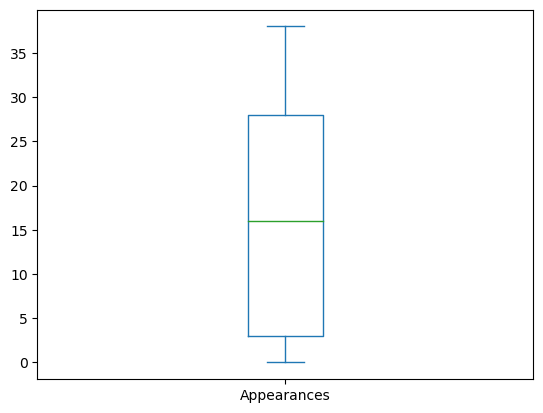

```python
playerStatsAllLeagues['Appearances'].plot(kind='box')
```

#### Goals:

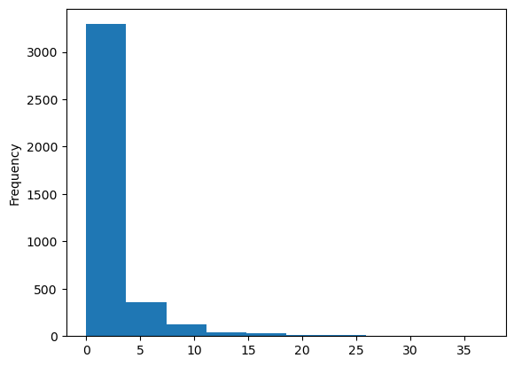

```python
playerStatsAllLeagues['Goals'].plot(kind='hist', bins=10)
```

Door gebruik te maken van dit histogram is er te zien hoe vaak het voorkomt dat een speler een goal scoort en ook hoe veel goals de speler dan scoort.

### Portfolio assignment 7

15 min: Look at the histogram of at least 2 columns with numerical data in the dataset that you chose in portfolio assignment 4. Do you recognise the distribution? Does it look like a uniform or normal distribution or something else? If it doesn't look like a uniform or normal distribution, take a quick look here to see if you can find the distribution shape: https://www.itl.nist.gov/div898/handbook/eda/section3/eda366.htm

```python
import pandas as pd
playerStats = pd.read_csv('playerStats.csv', sep=',')
```

```python
playerStats.head()
```

|  | League | Team | Season | KEY | Player | Position | Appearances | Goals | Started | Started As A Sub | ... | Minutes per Yellow Cards | Sent Off | Straight Red Card | Two Yellow Cards | Red - First Half | Red - Second Half | Red - Home | Red - Away | Red - Minutes Played | Minutes per Red Cards |
| --- | --- | --- | --- | --- | --- | --- | --- | --- | --- | --- | --- | --- | --- | --- | --- | --- | --- | --- | --- | --- | --- |
| 0 | Premier League | Chelsea | 2016/17 | Premier League\|Chelsea\|2016/17 | NaN | NaN | NaN | 83.0 | NaN | NaN | ... | NaN | NaN | NaN | NaN | NaN | NaN | NaN | NaN | NaN | NaN |
| 1 | Premier League | Chelsea | 2016/17 | Premier League\|Chelsea\|2016/17 | Cesar Azpilicueta | Defender | 38.0 | 1.0 | 38.0 | 0.0 | ... | 855 | NaN | NaN | NaN | NaN | NaN | NaN | NaN | NaN | NaN |
| 2 | Premier League | Chelsea | 2016/17 | Premier League\|Chelsea\|2016/17 | Gary Cahill | Defender | 37.0 | 6.0 | 36.0 | 2.0 | ... | 659.2 | NaN | NaN | NaN | NaN | NaN | NaN | NaN | NaN | NaN |
| 3 | Premier League | Chelsea | 2016/17 | Premier League\|Chelsea\|2016/17 | Eden Hazard | Midfielder | 36.0 | 16.0 | 36.0 | 0.0 | ... | 1002 | NaN | NaN | NaN | NaN | NaN | NaN | NaN | NaN | NaN |
| 4 | Premier League | Chelsea | 2016/17 | Premier League\|Chelsea\|2016/17 | Thibaut Courtois | Goalkeeper | 36.0 | 0.0 | 36.0 | 0.0 | ... | 3240 | NaN | NaN | NaN | NaN | NaN | NaN | NaN | NaN | NaN |

5 rows × 57 columns

```python
playerStatsAllLeagues = playerStats[(playerStats['Player'].notnull())]
```

#### Appearances:

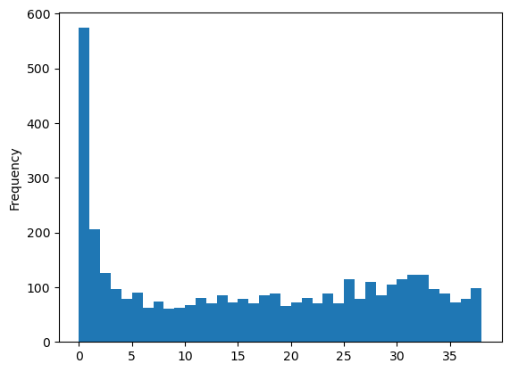

```python
playerStatsAllLeagues['Appearances'].plot(kind='hist', bins=38)
```

Het histogram dat is voortgekomen uit de geslecteerde data is zowel geen uniforme als geen normale verdeling. Dit diagram heeft niet veel gemeen met andere verdelingen en ik kan het daarom ook moeilijk plaatsen. Er is duidelijk een grote piek aan het begin die snel afneemt en later weer wat hoger wordt. Als ik dit histogram zou moeten koppelen aan een verdeling dan zou het koppelen aan de: Beta Distribution. Het heeft niet veel weg van deze verdeling, maar mijn motivatie voor deze keuze heeft te maken met de piek die rond het einde ontstaat alhoewel deze piek niet in de buurt komt van de hoogte van de eerste piek.

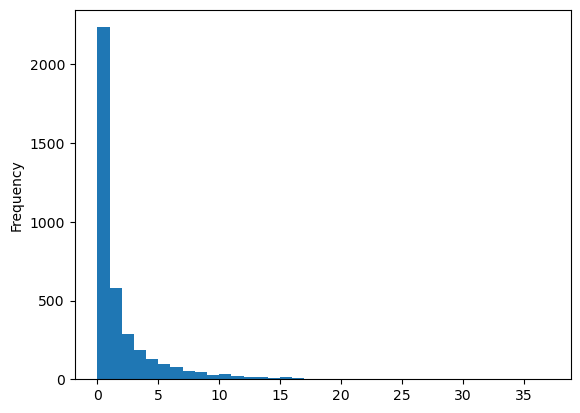

```python
playerStatsAllLeagues['Goals'].plot(kind='hist', bins=37)
```

Het histogram dat is voortgekomen uit de geslecteerde data is zowel geen uniforme als geen normale verdeling. Wel heeft het diagram veel weg van een: F Distribution. Dit vanwege de hoge piek aan het begin waarna een snelle, grote afname volgt.

### Portfolio assignment 8

15 min:

- Calculate the 90%, 95%, 99% and 99.99% confidence interval for at least 2 columns with numerical data in the dataset that you chose in portfolio assignment 4. Do you see the impact the confidence has on the interval?
- Now calculate the 95% confidence interval again but use only the first 10% of your rows. Compare this interval to the previous 95% confidence interval you calculated. Do you see the impact of having less data?

```python
import pandas as pd
playerStats = pd.read_csv('playerStats.csv', sep=',')
playerStatsAllLeagues = playerStats[(playerStats['Player'].notnull())]
import scipy.stats as st
```

#### Confidence interval all data

##### Appearances:

###### 90%:

```python
confidence = 0.90
st.t.interval(confidence, len(playerStatsAllLeagues)-1,
              loc=playerStatsAllLeagues['Appearances'].mean(),
              scale=st.sem(playerStatsAllLeagues['Appearances']))
```

```
(15.898504320269636, 16.55738183755701)
```

##### 95%:

```python
confidence = 0.95
st.t.interval(confidence, len(playerStatsAllLeagues)-1,
              loc=playerStatsAllLeagues['Appearances'].mean(),
              scale=st.sem(playerStatsAllLeagues['Appearances']))
```

```
(15.8353637278348, 16.620522429991848)
```

##### 99%:

```python
confidence = 0.99
st.t.interval(confidence, len(playerStatsAllLeagues)-1,
              loc=playerStatsAllLeagues['Appearances'].mean(),
              scale=st.sem(playerStatsAllLeagues['Appearances']))
```

```
(15.711913068051325, 16.743973089775324)
```

##### 99.99%:

```python
confidence = 0.9999
st.t.interval(confidence, len(playerStatsAllLeagues)-1,
              loc=playerStatsAllLeagues['Appearances'].mean(),
              scale=st.sem(playerStatsAllLeagues['Appearances']))
```

```
(15.448090369855716, 17.00779578797093)
```

#### Goals:

##### 90%:

```python
confidence = 0.90
st.t.interval(confidence, len(playerStatsAllLeagues)-1,
              loc=playerStatsAllLeagues['Goals'].mean(),
              scale=st.sem(playerStatsAllLeagues['Goals']))
```

```
(1.545605059551967, 1.726322495428628)
```

##### 95%:

```python
confidence = 0.95
st.t.interval(confidence, len(playerStatsAllLeagues)-1,
              loc=playerStatsAllLeagues['Goals'].mean(),
              scale=st.sem(playerStatsAllLeagues['Goals']))
```

```
(1.5282868089436676, 1.7436407460369274)
```

##### 99%:

```python
confidence = 0.99
st.t.interval(confidence, len(playerStatsAllLeagues)-1,
              loc=playerStatsAllLeagues['Goals'].mean(),
              scale=st.sem(playerStatsAllLeagues['Goals']))
```

```
(1.4944266663405303, 1.7775008886400647)
```

##### 99.99%:

```python
confidence = 0.9999
st.t.interval(confidence, len(playerStatsAllLeagues)-1,
              loc=playerStatsAllLeagues['Goals'].mean(),
              scale=st.sem(playerStatsAllLeagues['Goals']))
```

```
(1.4220651722949265, 1.8498623826856686)
```

Uit deze berekeningen is af te zien dat: hoe groter de de confidence, hoe groter het gat is tussen tusssen de twee getallen van het interval. Ofwel, doordat er meer vertrouwen moet zijn in het resultaat dat wordt aangeleverd word het gat tussen de twee getallen van het interval groter. Hiermee is dus ook de kans groter dat het gezochte getal tussen de twee getllen van het interval in licht.

#### Confidence interval 10%

##### Appearances:

###### All of the data:

```python
confidence = 0.95
st.t.interval(confidence, len(playerStatsAllLeagues)-1,
              loc=playerStatsAllLeagues['Appearances'].mean(),
              scale=st.sem(playerStatsAllLeagues['Appearances']))
```

```
(15.8353637278348, 16.620522429991848)
```

##### 10% of the data:

```python
playerStatsAllLeagues10 = playerStatsAllLeagues.head(int(len(playerStatsAllLeagues)*0.1))
confidence = 0.95
st.t.interval(confidence, len(playerStatsAllLeagues10)-1,
              loc=playerStatsAllLeagues10['Appearances'].mean(),
              scale=st.sem(playerStatsAllLeagues10['Appearances']))
```

```
(16.693585216578757, 19.332321519172535)
```

##### All of the data:

```python
confidence = 0.95
st.t.interval(confidence, len(playerStatsAllLeagues)-1,
              loc=playerStatsAllLeagues['Goals'].mean(),
              scale=st.sem(playerStatsAllLeagues['Goals']))
```

```
(1.5282868089436676, 1.7436407460369274)
```

##### 10% of the data:

```python
playerStatsAllLeagues10 = playerStatsAllLeagues.head(int(len(playerStatsAllLeagues)*0.1))
confidence = 0.95
st.t.interval(confidence, len(playerStatsAllLeagues10)-1,
              loc=playerStatsAllLeagues10['Goals'].mean(),
              scale=st.sem(playerStatsAllLeagues10['Goals']))
```

```
(1.6534990924963946, 2.444946503358528)
```

Uit deze berekingen is op te merken dat: hoe meer data beschikbaar wordt gesteld, hoe kleiner het betrouwbaarheidsinterval. Doordat er dus minder data wordt gebruikt bij de berekingen met 10%, gaan de twee getallen van het interval verder uit elkaar liggen.

### Portfolio assignment 9

25 min: Perform a bivariate analysis on the columns with numerical data in the penguins dataset.

- Use corr() on the DataFrame to calculate all the correlations. Use the code example above to show the correlation table with colors.
- Look at the corrrelations. Do they match your expectations?
- Show a scatter plot for
  - The strongest positive correlation
  - The strongest negative correlation
  - The weakest correlation

```python
import seaborn as sns
penguins = sns.load_dataset("penguins")
```

#### Correlation:

```python
penguins.corr().style.background_gradient(cmap='flare', axis=None).set_precision(2)
```

|  | bill_length_mm | bill_depth_mm | flipper_length_mm | body_mass_g |
| --- | --- | --- | --- | --- |
| bill_length_mm | 1.00 | -0.24 | 0.66 | 0.60 |
| bill_depth_mm | -0.24 | 1.00 | -0.58 | -0.47 |
| flipper_length_mm | 0.66 | -0.58 | 1.00 | 0.87 |
| body_mass_g | 0.60 | -0.47 | 0.87 | 1.00 |

Dit resultaat is naar verwachting, aangezien het te verwachten is dat de lengte van de flipper groeit wanneer de algemene lichaamsmassa groter wordt. Verder is het wel vreemd dat de lengte van de bek in slechte correlatie is ten opzichte van de diepte van de bek.

#### Scatter plots

##### Strongest positive correlation:

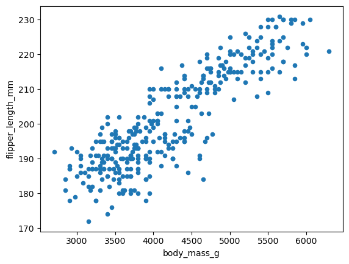

```python
penguins.plot(kind='scatter', x='body_mass_g', y='flipper_length_mm')
```

#### Strongest negative correlation:

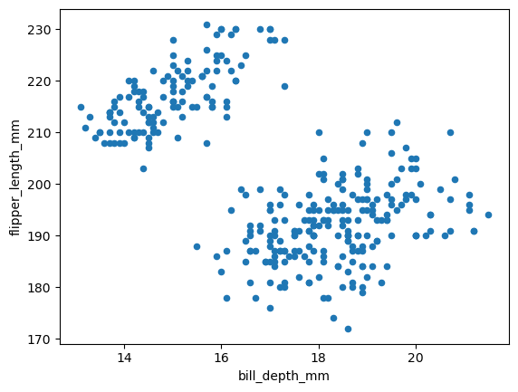

```python
penguins.plot(kind='scatter', x='bill_depth_mm', y='flipper_length_mm')
```

#### Weakest correlation:

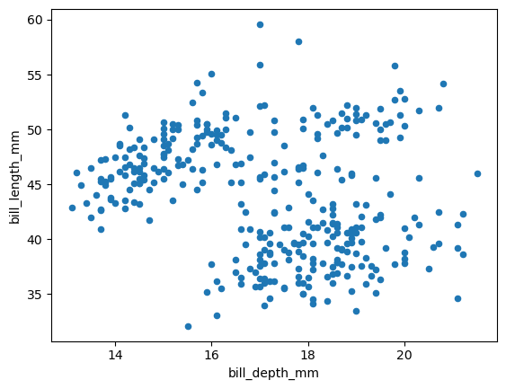

```python
penguins.plot(kind='scatter', x='bill_depth_mm', y='bill_length_mm')
```

### Portfolio assignment 10

15 min: Perform a bivariate analysis (Pearson correlation and scatter plot) on at least 1 combination of 2 columns with numeric data in the dataset that you chose in portfolio assignment 4. Does the correlation and scatter plot match your expectations? Add your answer to your notebook. Commit the Notebook to your portfolio when you're finished.

```python
import pandas as pd
type_dict = {'Team': 'object', 'Season': 'object', 'KEY': 'object', 'Player': 'object', 'Position': 'object', 'Appearances': 'float64', 'Goals': 'float64', 'Started': 'float64', 'Started As A Sub': 'float64', 'Came On': 'float64', 'Taken Off': 'float64', 'Own Goals': 'float64', 'Type Of Goal': 'object', 'First Half': 'float64', 'Second Half': 'float64', 'First Scorer': 'object', 'Last Scorer': 'object', 'Home': 'float64', 'Away': 'float64', 'Right Foot': 'float64', 'Left Foot': 'float64', 'Header': 'float64', 'Other Method': 'float64', 'Open Play': 'float64', 'Cross': 'float64', 'Free Kick': 'float64', 'Direct Free Kick': 'float64', 'Throw In': 'float64', 'Penalty': 'float64', 'Corner': 'float64', 'Other Type Of Play': 'float64', 'Minutes played': 'float64', 'Min/goal': 'float64', 'Assists': 'float64', '% Assists': 'float64', 'Leading Recipient': 'object', 'Recipient Goals': 'float64', 'CS': 'float64', '% Clean Sheets': 'float64', 'Hat Tricks': 'float64', 'Yellow Cards': 'float64', 'Yellow - First Half': 'float64', 'Yellow - Second Half': 'float64', 'Yellow - Home': 'float64', 'Yellow - Away': 'float64', 'Yelow - Minutes Played': 'float64', 'Minutes per Yellow Cards': 'float64', 'Sent Off': 'float64', 'Straight Red Card': 'float64', 'Two Yellow Cards': 'float64', 'Red - First Half': 'float64', 'Red - Second Half': 'float64', 'Red - Home': 'float64', 'Red - Away': 'float64', 'Red - Minutes Played': 'float64', 'Minutes per Red Cards': 'float64'}
playerStatsAllLeagues = pd.read_csv('merged-csv-files.csv', sep=',', dtype=type_dict)
```

The dataframe consists out of a lot of numerical columns, therefore the correlation schema get a bit big

```python
playerStatsAllLeagues.corr().style.background_gradient(cmap='RdYlBu_r', axis=None).set_precision(2)
```

|  | Appearances | Goals | Started | Started As A Sub | Came On | Taken Off | Own Goals | First Half | Second Half | Home | Away | Right Foot | Left Foot | Header | Other Method | Open Play | Cross | Free Kick | Direct Free Kick | Throw In | Penalty | Corner | Other Type Of Play | Minutes played | Min/goal | Assists | %Assists | Recipient Goals | CS | … |
| --- | --- | --- | --- | --- | --- | --- | --- | --- | --- | --- | --- | --- | --- | --- | --- | --- | --- | --- | --- | --- | --- | --- | --- | --- | --- | --- | --- | --- | --- | --- |
| Appearances | 1.00 | 0.47 | 0.94 | -0.08 | 0.32 | 0.58 | 0.15 | 0.32 | 0.35 | 0.34 | 0.34 | 0.33 | 0.25 | 0.26 | 0.11 | 0.36 | 0.26 | 0.15 | 0.14 | nan | 0.26 | 0.23 | 0.14 | 0.88 | 0.37 | 0.40 | 0.07 | 0.27 | 0.82 | … |
| Goals | 0.47 | 1.00 | 0.43 | -0.09 | 0.19 | 0.52 | -0.01 | 0.88 | 0.92 | 0.92 | 0.88 | 0.84 | 0.59 | 0.53 | 0.24 | 0.97 | 0.77 | 0.63 | 0.44 | 0.10 | 0.62 | 0.78 | 0.31 | 0.57 | -0.41 | 0.32 | -0.09 | 0.27 | -0.06 | … |
| Started | 0.94 | 0.43 | 1.00 | -0.27 | -0.01 | 0.47 | 0.18 | 0.32 | 0.30 | 0.31 | 0.33 | 0.32 | 0.25 | 0.25 | 0.14 | 0.35 | 0.27 | 0.17 | 0.18 | nan | 0.32 | 0.27 | 0.18 | 0.99 | 0.41 | 0.41 | 0.19 | 0.26 | 0.83 | … |
| Started As A Sub | -0.08 | -0.09 | -0.27 | 1.00 | 0.56 | 0.04 | -0.05 | -0.19 | -0.14 | -0.16 | -0.18 | -0.18 | -0.14 | -0.13 | -0.16 | -0.18 | -0.16 | -0.13 | -0.13 | nan | -0.23 | -0.19 | -0.16 | -0.51 | -0.21 | -0.14 | -0.26 | -0.06 | -0.59 | … |
| Came On | 0.32 | 0.19 | -0.01 | 0.56 | 1.00 | 0.40 | -0.06 | -0.08 | -0.01 | -0.04 | -0.07 | -0.06 | -0.07 | -0.04 | -0.11 | -0.06 | -0.10 | -0.08 | -0.12 | nan | -0.20 | -0.13 | -0.12 | -0.42 | -0.16 | -0.10 | -0.23 | -0.04 | -0.20 | … |
| Taken Off | 0.58 | 0.52 | 0.47 | 0.04 | 0.40 | 1.00 | -0.04 | 0.30 | 0.27 | 0.30 | 0.27 | 0.29 | 0.21 | 0.12 | 0.11 | 0.32 | 0.13 | 0.01 | -0.02 | nan | -0.01 | -0.02 | 0.14 | 0.30 | 0.15 | 0.14 | 0.01 | 0.13 | 0.02 | … |
| Own Goals | 0.15 | -0.01 | 0.18 | -0.05 | -0.06 | -0.04 | 1.00 | -0.05 | -0.05 | -0.06 | -0.04 | -0.05 | -0.04 | 0.01 | 0.02 | -0.05 | -0.03 | 0.07 | 0.07 | nan | -0.00 | 0.04 | 0.01 | 0.07 | 0.04 | -0.04 | 0.02 | -0.02 | 0.04 | … |
| First Half | 0.32 | 0.88 | 0.32 | -0.19 | -0.08 | 0.30 | -0.05 | 1.00 | 0.64 | 0.80 | 0.77 | 0.73 | 0.49 | 0.46 | 0.15 | 0.79 | 0.51 | 0.16 | 0.19 | nan | 0.42 | 0.20 | 0.22 | 0.46 | -0.39 | 0.25 | -0.09 | 0.22 | -0.33 | … |
| Second Half | 0.35 | 0.92 | 0.30 | -0.14 | -0.01 | 0.27 | -0.05 | 0.64 | 1.00 | 0.85 | 0.80 | 0.76 | 0.54 | 0.48 | 0.18 | 0.82 | 0.50 | 0.16 | 0.22 | nan | 0.44 | 0.25 | 0.22 | 0.47 | -0.38 | 0.27 | -0.09 | 0.24 | -0.23 | … |
| Home | 0.34 | 0.92 | 0.31 | -0.16 | -0.04 | 0.30 | -0.06 | 0.80 | 0.85 | 1.00 | 0.63 | 0.76 | 0.53 | 0.49 | 0.17 | 0.82 | 0.53 | 0.19 | 0.22 | nan | 0.46 | 0.25 | 0.21 | 0.47 | -0.40 | 0.26 | -0.08 | 0.23 | -0.47 | … |
| Away | 0.34 | 0.88 | 0.33 | -0.18 | -0.07 | 0.27 | -0.04 | 0.77 | 0.80 | 0.63 | 1.00 | 0.73 | 0.49 | 0.43 | 0.19 | 0.79 | 0.47 | 0.12 | 0.20 | nan | 0.39 | 0.21 | 0.27 | 0.47 | -0.34 | 0.26 | -0.11 | 0.24 | -0.18 | … |
| Right Foot | 0.33 | 0.84 | 0.32 | -0.18 | -0.06 | 0.29 | -0.05 | 0.73 | 0.76 | 0.76 | 0.73 | 1.00 | 0.11 | 0.30 | -0.16 | 0.78 | 0.40 | 0.09 | 0.14 | nan | 0.50 | 0.15 | -0.17 | 0.40 | -0.32 | 0.24 | -0.08 | 0.19 | -0.34 | … |
| Left Foot | 0.25 | 0.59 | 0.25 | -0.14 | -0.07 | 0.21 | -0.04 | 0.49 | 0.54 | 0.53 | 0.49 | 0.11 | 1.00 | 0.16 | -0.10 | 0.58 | 0.20 | 0.09 | 0.36 | nan | 0.22 | 0.07 | -0.12 | 0.28 | -0.18 | 0.27 | 0.02 | 0.22 | -0.22 | … |
| Header | 0.26 | 0.53 | 0.25 | -0.13 | -0.04 | 0.12 | 0.01 | 0.46 | 0.48 | 0.49 | 0.43 | 0.30 | 0.16 | 1.00 | -0.00 | 0.32 | 0.61 | 0.31 | 0.02 | nan | 0.22 | 0.43 | 0.01 | 0.26 | -0.19 | 0.11 | -0.15 | 0.08 | -0.38 | … |
| Other Method | 0.11 | 0.24 | 0.14 | -0.16 | -0.11 | 0.11 | 0.02 | 0.15 | 0.18 | 0.17 | 0.19 | -0.16 | -0.10 | -0.00 | 1.00 | -0.18 | -0.12 | -0.03 | 0.21 | nan | -0.07 | -0.09 | 0.98 | 0.06 | -0.05 | -0.44 | -0.46 | -0.34 | nan | … |
| Open Play | 0.36 | 0.97 | 0.35 | -0.18 | -0.06 | 0.32 | -0.05 | 0.79 | 0.82 | 0.82 | 0.79 | 0.78 | 0.58 | 0.32 | -0.18 | 1.00 | 0.67 | 0.52 | 0.41 | 0.02 | 0.55 | 0.68 | -0.12 | 0.44 | -0.37 | 0.33 | -0.09 | 0.28 | -0.34 | … |
| Cross | 0.26 | 0.77 | 0.27 | -0.16 | -0.10 | 0.13 | -0.03 | 0.51 | 0.50 | 0.53 | 0.47 | 0.40 | 0.20 | 0.61 | -0.12 | 0.67 | 1.00 | 0.39 | 0.21 | 0.02 | 0.35 | 0.58 | -0.15 | 0.26 | -0.25 | 0.12 | -0.16 | 0.10 | nan | … |
| Free Kick | 0.15 | 0.63 | 0.17 | -0.13 | -0.08 | 0.01 | 0.07 | 0.16 | 0.16 | 0.19 | 0.12 | 0.09 | 0.09 | 0.31 | -0.03 | 0.52 | 0.39 | 1.00 | 0.15 | 0.07 | 0.28 | 0.46 | -0.13 | 0.15 | -0.02 | -0.05 | -0.05 | -0.05 | nan | … |
| Direct Free Kick | 0.14 | 0.44 | 0.18 | -0.13 | -0.12 | -0.02 | 0.07 | 0.19 | 0.22 | 0.22 | 0.20 | 0.14 | 0.36 | 0.02 | 0.21 | 0.41 | 0.21 | 0.15 | 1.00 | -0.06 | 0.18 | 0.18 | -0.03 | 0.11 | -0.08 | 0.26 | 0.15 | 0.19 | nan | … |
| Throw In | nan | 0.10 | nan | nan | nan | nan | nan | nan | nan | nan | nan | nan | nan | nan | nan | 0.02 | 0.02 | 0.07 | -0.06 | 1.00 | -0.52 | 0.01 | nan | nan | nan | nan | nan | nan | nan | … |
| Penalty | 0.26 | 0.62 | 0.32 | -0.23 | -0.20 | -0.01 | -0.00 | 0.42 | 0.44 | 0.46 | 0.39 | 0.50 | 0.22 | 0.22 | -0.07 | 0.55 | 0.35 | 0.28 | 0.18 | -0.52 | 1.00 | 0.37 | -0.06 | 0.29 | -0.16 | 0.13 | -0.03 | 0.09 | nan | … |
| Corner | 0.23 | 0.78 | 0.27 | -0.19 | -0.13 | -0.02 | 0.04 | 0.20 | 0.25 | 0.25 | 0.21 | 0.15 | 0.07 | 0.43 | -0.09 | 0.68 | 0.58 | 0.46 | 0.18 | 0.01 | 0.37 | 1.00 | -0.17 | 0.25 | -0.09 | 0.18 | -0.06 | 0.18 | nan | … |
| Other Type Of Play | 0.14 | 0.31 | 0.18 | -0.16 | -0.12 | 0.14 | 0.01 | 0.22 | 0.22 | 0.21 | 0.27 | -0.17 | -0.12 | 0.01 | 0.98 | -0.12 | -0.15 | -0.13 | -0.03 | nan | -0.06 | -0.17 | 1.00 | 0.07 | -0.06 | -0.40 | -0.46 | -0.25 | nan | … |
| Minutes played | 0.88 | 0.57 | 0.99 | -0.51 | -0.42 | 0.30 | 0.07 | 0.46 | 0.47 | 0.47 | 0.47 | 0.40 | 0.28 | 0.26 | 0.06 | 0.44 | 0.26 | 0.15 | 0.11 | nan | 0.29 | 0.25 | 0.07 | 1.00 | 0.41 | 0.40 | 0.26 | 0.25 | nan | … |
| Min/goal | 0.37 | -0.41 | 0.41 | -0.21 | -0.16 | 0.15 | 0.04 | -0.39 | -0.38 | -0.40 | -0.34 | -0.32 | -0.18 | -0.19 | -0.05 | -0.37 | -0.25 | -0.02 | -0.08 | nan | -0.16 | -0.09 | -0.06 | 0.41 | 1.00 | 0.01 | 0.33 | -0.06 | nan | … |
| Assists | 0.40 | 0.32 | 0.41 | -0.14 | -0.10 | 0.14 | -0.04 | 0.25 | 0.27 | 0.26 | 0.26 | 0.24 | 0.27 | 0.11 | -0.44 | 0.33 | 0.12 | -0.05 | 0.26 | nan | 0.13 | 0.18 | -0.40 | 0.40 | 0.01 | 1.00 | 0.50 | 0.63 | nan | … |
| %Assists | 0.07 | -0.09 | 0.19 | -0.26 | -0.23 | 0.01 | 0.02 | -0.09 | -0.09 | -0.08 | -0.11 | -0.08 | 0.02 | -0.15 | -0.46 | -0.09 | -0.16 | -0.05 | 0.15 | nan | -0.03 | -0.06 | -0.46 | 0.26 | 0.33 | 0.50 | 1.00 | 0.28 | nan | … |
| Recipient Goals | 0.27 | 0.27 | 0.26 | -0.06 | -0.04 | 0.13 | -0.02 | 0.22 | 0.24 | 0.23 | 0.24 | 0.19 | 0.22 | 0.08 | -0.34 | 0.28 | 0.10 | -0.05 | 0.19 | nan | 0.09 | 0.18 | -0.25 | 0.25 | -0.06 | 0.63 | 0.28 | 1.00 | nan | … |
| CS | 0.82 | -0.06 | 0.83 | -0.59 | -0.20 | 0.02 | 0.04 | -0.33 | -0.23 | -0.47 | -0.18 | -0.34 | -0.22 | -0.38 | nan | -0.34 | nan | nan | nan | nan | nan | nan | nan | nan | nan | nan | nan | nan | 1.00 | … |
| %Clean Sheets | 0.12 | -0.06 | 0.12 | -0.09 | -0.04 | -0.05 | -0.06 | -0.33 | -0.21 | -0.42 | -0.14 | -0.30 | -0.22 | -0.37 | nan | -0.34 | nan | nan | nan | nan | nan | nan | nan | nan | nan | nan | nan | nan | 0.40 | … |
| Hat Tricks | 0.14 | 0.58 | 0.20 | -0.18 | -0.17 | -0.15 | -0.04 | 0.47 | 0.57 | 0.57 | 0.45 | 0.41 | 0.30 | 0.31 | -0.09 | 0.50 | 0.30 | 0.08 | 0.39 | nan | 0.27 | 0.06 | -0.15 | 0.22 | -0.30 | 0.36 | 0.03 | 0.20 | nan | … |
| Yellow Cards | 0.47 | 0.10 | 0.50 | -0.26 | -0.14 | 0.12 | 0.08 | -0.00 | 0.00 | 0.00 | -0.00 | 0.01 | -0.01 | 0.03 | -0.04 | -0.01 | 0.04 | 0.06 | 0.04 | nan | 0.10 | 0.06 | -0.05 | 0.36 | 0.19 | 0.05 | 0.04 | 0.04 | 0.03 | … |
| Yellow First Half | 0.28 | 0.03 | 0.32 | -0.20 | -0.14 | 0.06 | 0.06 | -0.02 | -0.02 | -0.02 | -0.03 | -0.02 | -0.02 | -0.00 | 0.01 | -0.04 | 0.01 | 0.04 | 0.05 | nan | 0.05 | 0.03 | 0.00 | 0.21 | 0.12 | 0.02 | 0.02 | 0.00 | -0.15 | … |
| Yellow Second Half | 0.41 | 0.09 | 0.42 | -0.22 | -0.10 | 0.08 | 0.05 | 0.01 | 0.01 | 0.02 | 0.01 | 0.02 | -0.00 | 0.03 | -0.06 | 0.01 | 0.04 | 0.03 | 0.00 | nan | 0.11 | 0.05 | -0.07 | 0.30 | 0.15 | 0.05 | 0.04 | 0.04 | 0.04 | … |
| Yellow Home | 0.35 | 0.07 | 0.38 | -0.21 | -0.12 | 0.07 | 0.04 | 0.00 | -0.01 | 0.00 | -0.02 | -0.01 | -0.01 | 0.02 | -0.02 | -0.02 | 0.04 | 0.08 | -0.03 | nan | 0.08 | 0.02 | -0.02 | 0.25 | 0.12 | 0.02 | 0.05 | 0.03 | -0.11 | … |
| Yellow Away | 0.37 | 0.06 | 0.40 | -0.22 | -0.13 | 0.06 | 0.06 | -0.02 | -0.01 | -0.01 | -0.01 | -0.00 | -0.01 | -0.00 | 0.00 | -0.01 | -0.00 | 0.02 | 0.07 | nan | 0.07 | 0.04 | -0.01 | 0.29 | 0.14 | 0.04 | -0.00 | 0.02 | 0.07 | … |
| Yellow Minutes Played | 0.93 | 0.33 | 0.99 | -0.52 | -0.29 | 0.21 | 0.14 | 0.30 | 0.29 | 0.30 | 0.31 | 0.30 | 0.23 | 0.25 | 0.10 | 0.33 | 0.27 | 0.17 | 0.17 | nan | 0.31 | 0.26 | 0.11 | 1.00 | 0.33 | 0.39 | 0.18 | 0.26 | 0.74 | … |
| Minutes per Yellow Cards | 0.37 | 0.17 | 0.38 | -0.18 | -0.10 | 0.09 | 0.03 | 0.19 | 0.20 | 0.20 | 0.21 | 0.19 | 0.16 | 0.12 | 0.08 | 0.24 | 0.13 | 0.03 | 0.02 | nan | 0.06 | 0.09 | 0.11 | 0.23 | 0.03 | 0.12 | 0.04 | 0.08 | 0.52 | … |
| Sent Off | 0.08 | -0.02 | 0.09 | -0.06 | -0.05 | -0.04 | 0.07 | 0.01 | -0.02 | -0.04 | -0.05 | -0.04 | -0.02 | -0.06 | -0.13 | -0.00 | -0.02 | -0.11 | -0.12 | nan | 0.04 | -0.00 | nan | -0.06 | -0.08 | -0.07 | -0.05 | 0.00 | -0.12 | … |
| Straight Red Card | 0.04 | 0.03 | 0.05 | -0.06 | -0.04 | -0.03 | 0.00 | 0.08 | 0.04 | 0.02 | 0.02 | 0.00 | 0.05 | -0.00 | -0.07 | 0.07 | -0.00 | -0.09 | -0.07 | nan | 0.09 | -0.00 | nan | -0.05 | -0.07 | -0.03 | -0.04 | 0.08 | -0.10 | … |
| Two Yellow Cards | 0.07 | -0.04 | 0.09 | -0.04 | -0.07 | -0.06 | 0.07 | -0.08 | -0.05 | -0.09 | -0.08 | -0.06 | -0.07 | -0.10 | -0.07 | -0.08 | 0.04 | -0.07 | -0.11 | nan | -0.01 | 0.01 | nan | 0.05 | 0.09 | -0.04 | 0.05 | -0.00 | nan | … |
| Red First Half | -0.02 | 0.04 | 0.02 | -0.05 | -0.10 | -0.05 | 0.06 | 0.26 | 0.08 | 0.12 | 0.24 | 0.15 | 0.14 | 0.15 | nan | 0.28 | 0.06 | -0.06 | nan | nan | nan | 0.03 | nan | 0.06 | -0.24 | -0.05 | -0.14 | -0.10 | -0.10 | … |
| Red Second Half | 0.08 | -0.01 | 0.10 | -0.06 | -0.05 | -0.02 | 0.07 | -0.01 | -0.02 | -0.03 | -0.06 | -0.02 | -0.03 | -0.08 | -0.11 | -0.01 | -0.03 | -0.11 | -0.11 | nan | 0.02 | 0.03 | nan | -0.10 | -0.10 | -0.07 | 0.01 | -0.06 | -0.16 | … |
| Red Home | 0.10 | -0.03 | 0.11 | -0.07 | -0.06 | -0.02 | 0.06 | -0.04 | -0.06 | -0.09 | -0.04 | -0.06 | 0.00 | 0.01 | -0.14 | -0.09 | 0.06 | -0.09 | -0.08 | nan | 0.05 | 0.11 | nan | 0.09 | 0.13 | -0.03 | 0.01 | 0.05 | 0.12 | … |
| Red Away | 0.06 | -0.01 | 0.06 | -0.03 | -0.02 | -0.06 | 0.09 | 0.02 | -0.02 | -0.03 | -0.07 | -0.04 | -0.03 | -0.07 | -0.06 | -0.03 | -0.03 | -0.09 | -0.09 | nan | 0.02 | 0.03 | nan | 0.01 | -0.16 | -0.03 | -0.03 | 0.01 | -0.14 | … |
| Red Minutes Played | 0.93 | 0.27 | 0.99 | -0.57 | -0.33 | 0.13 | 0.12 | 0.22 | 0.20 | 0.21 | 0.20 | 0.23 | 0.13 | 0.20 | 0.03 | 0.22 | 0.18 | 0.08 | 0.18 | nan | 0.31 | 0.23 | 0.06 | 1.00 | 0.35 | 0.30 | 0.10 | 0.20 | 0.71 | … |
| Minutes per Red Cards | 0.87 | 0.27 | 0.92 | -0.52 | -0.29 | 0.14 | 0.09 | 0.22 | 0.20 | 0.22 | 0.21 | 0.24 | 0.13 | 0.20 | 0.08 | 0.21 | 0.17 | 0.14 | 0.22 | nan | 0.28 | 0.19 | 0.06 | 0.91 | 0.33 | 0.30 | 0.11 | 0.17 | 0.73 | … |

Still this schema can be used to determine some interesting correlations.

##### High correlation - not expected

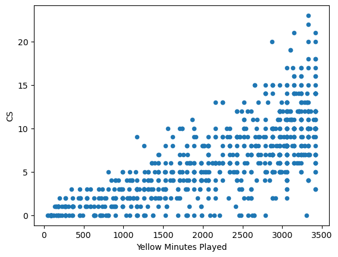

```python
playerStatsAllLeagues.plot(kind='scatter', x='Yellow Minutes Played', y='CS')
```

##### Low correlation - not expected

The correlation between goals scored from crosses and goals scored with headers is 0.61. Although this isn't very low, the expectation was that this number would be way higher. The scatter plot below provides insight in this surprising outcome. The expactation for the correlation was that the amount of headers scored would be linked to the amount of goals scored from crosses, because crosses are mostly finished with eiter volleys or headers. Though in the plot can be seen that there are lots of headers that are not scored from a cross. This statistic is fairly strange, because currently it is not yet known how one can score with the head without receiving a pass through the air. This will be looked at further in the future.

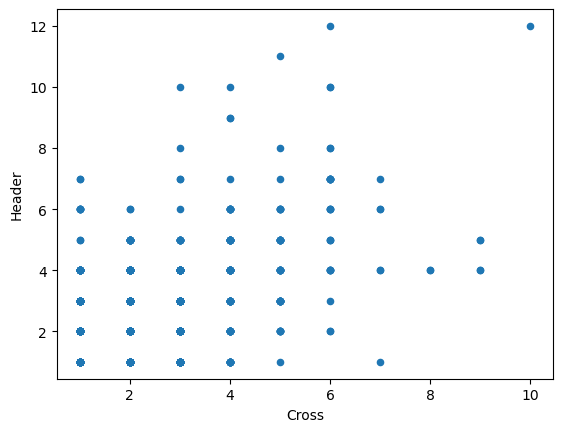

```python
playerStatsAllLeagues.plot(kind='scatter', x='Cross', y='Header')
```

##### High correlation - expected

The correlation between the appearances and the minutes played is with 0.88 one of the higher (relevant) correlation in the table. This was also expected beforehand. It seemed logical that: the more appearances the more minutes played. And the scatter plot below supports this statement. There was expected a bit more spreading at the top left of the plot, because a appearance is also added when a player is subbed in. Some players only play a few matches as sub and then play 5 to 10 minutes when they are subbed in. these players are the cause of the spread on the left side of the plot. The reason for that there is a diagnoal line in the plot is caused by that a player can only play a maximum amount of 90 minutes per appearance.

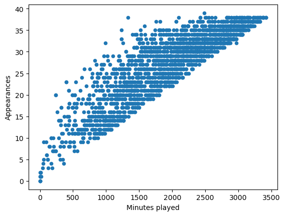

```python
playerStatsAllLeagues.plot(kind='scatter', x='Minutes played', y='Appearances')
```

### Portfolio assignment 11

20 min: Do a Numerical VS Categorical bivariate analysis on the penguins dataset.

- Choose one of the categorical columns: species, island or sex
- use .groupby('').mean() too look at the means of the numerical columns. Does it look like there is a difference between categories?
- Use the seaborn barplot to plot the mean and confidence. Create this plot for each of the numerical columns (bill_length_mm bill_depth_mm, flipper_length_mm, body_mass_g)
- For each of the plots, write a conclusion: Is there a statistically significant difference for this numerical column for each category?
- Optional: Repeat this proces for the other two categorical columns

```python
import pandas as pd
import seaborn as sns
penguins = sns.load_dataset("penguins")
penguins.groupby('island').mean()
```

| island | bill_length_mm | bill_depth_mm | flipper_length_mm | body_mass_g |
| --- | --- | --- | --- | --- |
| Biscoe | 45.257485 | 15.874850 | 209.706587 | 4716.017964 |
| Dream | 44.167742 | 18.344355 | 193.072581 | 3712.903226 |
| Torgersen | 38.950980 | 18.429412 | 191.196078 | 3706.372549 |

#### barplots

##### bill_length_mm

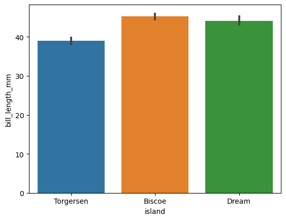

```python
sns.barplot(y="bill_length_mm", x="island", data=penguins)
```

In the barplot is visible that the confidence interval for the island 'Torgersen', is not overlapping with the other islands. So it can be said that there is a statistically significant difference between 'Torgersen' and the other islands. The intervals og the other two islands: 'Biscoe' and 'Dream' are overlapping, so there is no statistically significant difference between these two islands.

##### bill_depth_mm

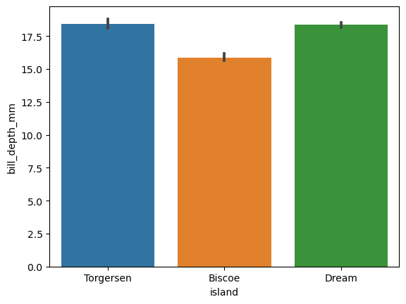

```python
sns.barplot(y="bill_depth_mm", x="island", data=penguins)
```

The confidence intervals of the islands: 'Torgersen' and 'Dream' are overlapping eachother, so it can be said that there is not a statistically significant difference between these island. But between 'Biscoe' and the other two islands there can be found a statistically significant difference, because the intervals are nowhere near eachother.

##### flipper_length_mm

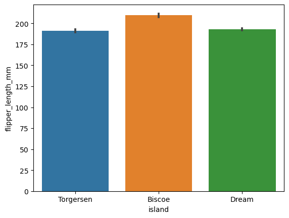

```python
sns.barplot(y="flipper_length_mm", x="island", data=penguins)
```

The confidence intervals of the islands: 'Torgersen' and 'Dream' are overlapping eachother, so it can be said that there is not a statistically significant difference between these island. But between 'Biscoe' and the other two islands there can be found a statistically significant difference, because the intervals are nowhere near eachother.

##### body_mass_g

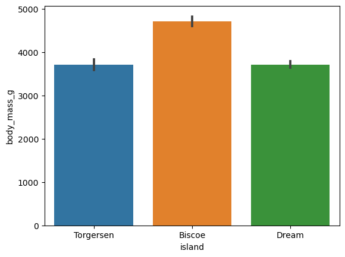

```python
sns.barplot(y="body_mass_g", x="island", data=penguins)
```

The confidence intervals of the islands: 'Torgersen' and 'Dream' are overlapping eachother, so it can be said that there is not a statistically significant difference between these island. But between 'Biscoe' and the other two islands there can be found a statistically significant difference, because the intervals are nowhere near eachother.

### Portfolio assignment 12

30 min: Perform a bivariate analysis on at least 3 combinations of a numerical column with a categorical column in the dataset that you chose in portfolio assignment 4. Use *.groupby('columnname').mean()* to calculate the means. Is there a difference between categories? Then use seaborn barplots to check if there is a statistically significant difference.

```python
import pandas as pd
import seaborn as sns
type_dict = {'Team': 'object', 'Season': 'object', 'KEY': 'object', 'Player': 'object', 'Position': 'object', 'Appearances': 'float64', 'Goals': 'float64', 'Started': 'float64', 'Started As A Sub': 'float64', 'Came On': 'float64', 'Taken Off': 'float64', 'Own Goals': 'float64', 'Type Of Goal': 'object', 'First Half': 'float64', 'Second Half': 'float64', 'First Scorer': 'object', 'Last Scorer': 'object', 'Home': 'float64', 'Away': 'float64', 'Right Foot': 'float64', 'Left Foot': 'float64', 'Header': 'float64', 'Other Method': 'float64', 'Open Play': 'float64', 'Cross': 'float64', 'Free Kick': 'float64', 'Direct Free Kick': 'float64', 'Throw In': 'float64', 'Penalty': 'float64', 'Corner': 'float64', 'Other Type Of Play': 'float64', 'Minutes played': 'float64', 'Min/goal': 'float64', 'Assists': 'float64', '% Assists': 'float64', 'Leading Recipient': 'object', 'Recipient Goals': 'float64', 'CS': 'float64', '% Clean Sheets': 'float64', 'Hat Tricks': 'float64', 'Yellow Cards': 'float64', 'Yellow - First Half': 'float64', 'Yellow - Second Half': 'float64', 'Yellow - Home': 'float64', 'Yellow - Away': 'float64', 'Yelow - Minutes Played': 'float64', 'Minutes per Yellow Cards': 'float64', 'Sent Off': 'float64', 'Straight Red Card': 'float64', 'Two Yellow Cards': 'float64', 'Red - First Half': 'float64', 'Red - Second Half': 'float64', 'Red - Home': 'float64', 'Red - Away': 'float64', 'Red - Minutes Played': 'float64', 'Minutes per Red Cards': 'float64'}
playerStatsAllLeagues = pd.read_csv('merged-csv-files.csv', sep=',', dtype=type_dict)
playerStatsAllLeaguesNoTeams = playerStatsAllLeagues[playerStatsAllLeagues['Position'] != "Other"];
```

#### Position

```python
playerStatsAllLeaguesNoTeams.groupby('Position').mean()
```

| Position | Appearances | Goals | Started | Started As A Sub | Came On | Taken Off | Own Goals | First Half | Second Half | Home | ... | Minutes per Yellow Cards | Sent Off | Straight Red Card | Two Yellow Cards | Red First Half | Red Second Half | Red Home | Red Away | Red Minutes Played | Minutes per Red Cards |
| --- | --- | --- | --- | --- | --- | --- | --- | --- | --- | --- | --- | --- | --- | --- | --- | --- | --- | --- | --- | --- | --- |
| Defender | 15.477998 | 0.598422 | 13.812153 | 7.316406 | 1.665845 | 1.589671 | 0.093184 | 1.371410 | 1.445283 | 1.470776 | ... | 543.466796 | 1.126516 | 1.053922 | 1.061588 | 1.036789 | 1.093923 | 1.055102 | 1.093575 | 1859.409012 | 1734.242929 |
| Forward | 16.080618 | 3.614597 | 10.557810 | 9.462856 | 5.522808 | 4.844908 | 0.010985 | 3.340400 | 3.696512 | 3.837209 | ... | 625.175608 | 1.069767 | 1.056277 | 1.017964 | 1.023529 | 1.058252 | 1.020513 | 1.053922 | 1703.235142 | 1648.393411 |
| Goalkeeper | 10.151019 | 0.001336 | 10.021383 | 11.595389 | 0.129636 | 0.097227 | 0.034414 | NaN | 1.000000 | 1.000000 | ... | 1553.533577 | 1.034483 | 1.036364 | 1.000000 | 1.043478 | 1.014085 | 1.042553 | 1.028986 | 2044.333333 | 1975.000000 |
| Midfielder | 16.544783 | 1.548425 | 12.573031 | 8.471063 | 3.971752 | 4.414665 | 0.020079 | 2.059015 | 2.227110 | 2.261467 | ... | 546.724438 | 1.091610 | 1.036122 | 1.059567 | 1.004651 | 1.081464 | 1.051064 | 1.047619 | 1775.807136 | 1691.018631 |

4 rows × 47 columns

From this table can be seen that, between positions, there are big differences in values. In upcomming barplots a few of these differnces will be analyzed further.

#### Goals

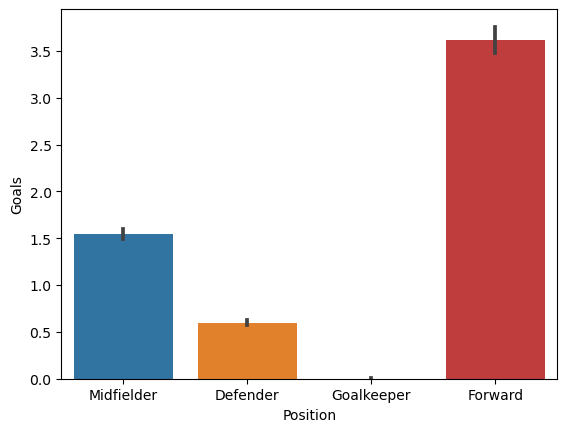

```python
sns.barplot(y="Goals", x="Position", data=playerStatsAllLeaguesNoTeams)
```

#### Assists

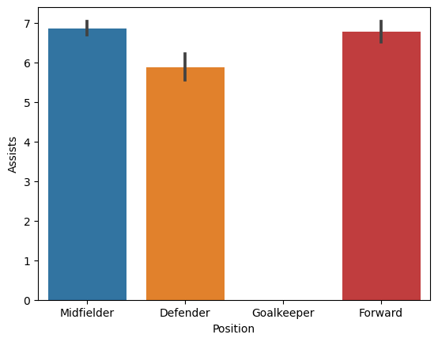

```python
sns.barplot(y="Assists", x="Position", data=playerStatsAllLeaguesNoTeams)
```

#### Came on

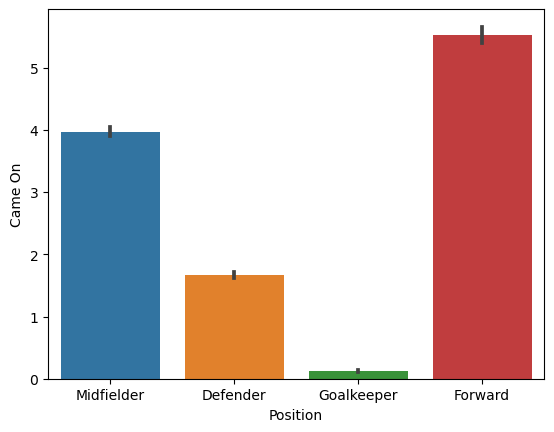

```python
sns.barplot(y="Came On", x="Position", data=playerStatsAllLeaguesNoTeams)
```

### Portfolio assignment 13

10 min: Do a bivariate analysis on the penguins dataset for the following combination of columns:

- species VS sex
- island VS sex

For this bivariate analysis, at least perform the following tasks:

- Do you expect their to be a correlation between the two columns?
- Create a contingency table. Do you observe different ratios between categories here?
- Create a bar plot for this contingency table. Do you observe different ratios between categories here?
- Do a chi-squared test. What does the result say? What's the chance of there being a correlation between the two columns?

[figure not shown]

```python
import pandas as pd
import seaborn as sns
from scipy.stats import chi2_contingency
penguins = sns.load_dataset("penguins")
def create_contingency_table(dataset, column1, column2):
    return dataset.groupby([column1, column2]).size().unstack(column1, fill_value=0)
def check_cat_vs_cat_correlation(dataset, column1, column2):
    contingency_table = create_contingency_table(dataset, column1, column2)
    chi2 = chi2_contingency(contingency_table)
    p_value = chi2[1]
    odds_of_correlation = 1 - p_value
    print(f"The odds of a correlation between {column1} and {column2} is {odds_of_correlation * 100}% (Based on a p value of {p_value}).")
    print("This percentage needs to be at least 95% for a significant correlation.")
```

#### Species & Sex

There is no correlation expected between species and sex. I can not think of a reason why there would be a significant correlation with these two columns. Both sexes are needed in order to not go extinct, so a big difference between sexes among species would not suggest anything good.

```python
penguinsContingencyTable = create_contingency_table(penguins, 'species','sex')
penguinsContingencyTable
```

| species sex | Adelie | Chinstrap | Gentoo |
| --- | --- | --- | --- |
| Female | 73 | 34 | 58 |
| Male | 73 | 34 | 61 |

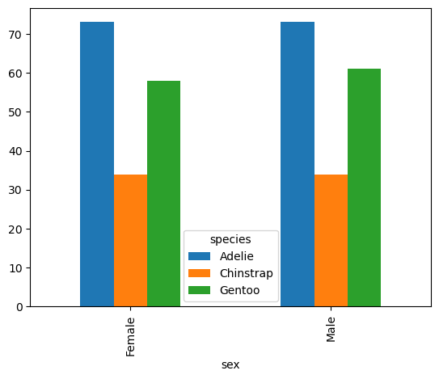

```python
penguinsContingencyTable.plot(kind='bar')
```

```python
check_cat_vs_cat_correlation(penguins, 'species','sex')
```

```
The odds of a correlation between species and sex is 2.4010631023415385% (Based on a p value of 0.9759893689765846).
This percentage needs to be at least 95% for a significant correlation.
```

The given correlation is not enough to state this as a significant correlation.

#### Island & Sex

For this analysis there is also no correlation expected, for the same reasons as the previous analysis.

```python
penguinsContingencyTable = create_contingency_table(penguins, 'island','sex')
penguinsContingencyTable
```

| island sex | Biscoe | Dream | Torgersen |
| --- | --- | --- | --- |
| Female | 80 | 61 | 24 |
| Male | 83 | 62 | 23 |

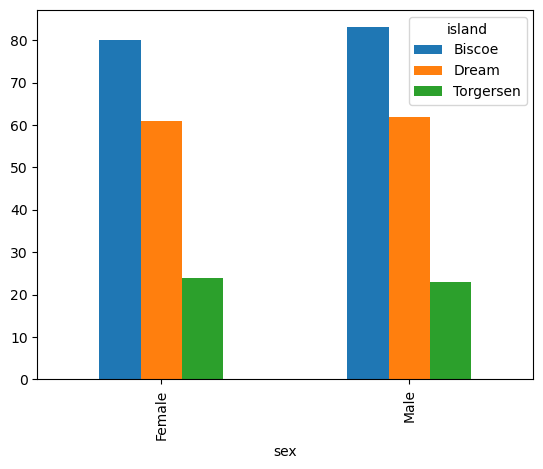

```python
penguinsContingencyTable.plot(kind='bar')
```

```python
check_cat_vs_cat_correlation(penguins, 'island','sex')
```

```
The odds of a correlation between island and sex is 2.8388770718934975% (Based on a p value of 0.971611229281065).
This percentage needs to be at least 95% for a significant correlation.
```

The given correlation is not enough to state this as a significant correlation

### Portfolio assignment 14

Perform a bivariate analysis on at least 1 combination of 2 columns with categorical data in the dataset that you chose in portfolio assignment 4.

- Do you expect their to be a correlation between the two columns?
- Create a contingency table. Do you observe different ratios between categories here?
- Create a bar plot for this contingency table. Do you observe different ratios between categories here?
- Do a chi-squared test. What does the result say? What's the chance of there being a correlation between the two columns?

[figure not shown]

```python
import pandas as pd
import seaborn as sns
from scipy.stats import chi2_contingency
type_dict = {'Team': 'object', 'Season': 'object', 'KEY': 'object', 'Player': 'object', 'Position': 'object', 'Appearances': 'float64', 'Goals': 'float64', 'Started': 'float64', 'Started As A Sub': 'float64', 'Came On': 'float64', 'Taken Off': 'float64', 'Own Goals': 'float64', 'Type Of Goal': 'object', 'First Half': 'float64', 'Second Half': 'float64', 'First Scorer': 'object', 'Last Scorer': 'object', 'Home': 'float64', 'Away': 'float64', 'Right Foot': 'float64', 'Left Foot': 'float64', 'Header': 'float64', 'Other Method': 'float64', 'Open Play': 'float64', 'Cross': 'float64', 'Free Kick': 'float64', 'Direct Free Kick': 'float64', 'Throw In': 'float64', 'Penalty': 'float64', 'Corner': 'float64', 'Other Type Of Play': 'float64', 'Minutes played': 'float64', 'Min/goal': 'float64', 'Assists': 'float64', '% Assists': 'float64', 'Leading Recipient': 'object', 'Recipient Goals': 'float64', 'CS': 'float64', '% Clean Sheets': 'float64', 'Hat Tricks': 'float64', 'Yellow Cards': 'float64', 'Yellow - First Half': 'float64', 'Yellow - Second Half': 'float64', 'Yellow - Home': 'float64', 'Yellow - Away': 'float64', 'Yelow - Minutes Played': 'float64', 'Minutes per Yellow Cards': 'float64', 'Sent Off': 'float64', 'Straight Red Card': 'float64', 'Two Yellow Cards': 'float64', 'Red - First Half': 'float64', 'Red - Second Half': 'float64', 'Red - Home': 'float64', 'Red - Away': 'float64', 'Red - Minutes Played': 'float64', 'Minutes per Red Cards': 'float64'}
playerStatsAllLeagues = pd.read_csv('merged-csv-files.csv', sep=',', dtype=type_dict)
playerStatsAllLeaguesNoTeams = playerStatsAllLeagues[playerStatsAllLeagues['Position'] != "Other"];

def create_contingency_table(dataset, column1, column2):
    return dataset.groupby([column1, column2]).size().unstack(column1, fill_value=0)
def check_cat_vs_cat_correlation(dataset, column1, column2):
    contingency_table = create_contingency_table(dataset, column1, column2)
    chi2 = chi2_contingency(contingency_table)
    p_value = chi2[1]
    odds_of_correlation = 1 - p_value
    print(f"The odds of a correlation between {column1} and {column2} is {odds_of_correlation * 100}% (Based on a p value of {p_value}).")
    print("This percentage needs to be at least 95% for a significant correlation.")
```

#### League & Position

I am expected a small correlation between the position and the league. I think all leagues have different play styles and require different players on different positions. This might also result in a difference between the number of players required on positions.

```python
playerStatsAllLeaguesNoTeamsContingencyTable = create_contingency_table(playerStatsAllLeaguesNoTeams, 'League', 'Position')
playerStatsAllLeaguesNoTeamsContingencyTable
```

| League Position | Bundesliga | Eredivisie | French Ligue 1 | La Liga | Premier League | Scottish Premiership | Serie A |
| --- | --- | --- | --- | --- | --- | --- | --- |
| Defender | 1044 | 854 | 1239 | 1320 | 1308 | 837 | 1511 |
| Forward | 706 | 554 | 915 | 855 | 796 | 659 | 886 |
| Goalkeeper | 395 | 346 | 450 | 458 | 454 | 296 | 594 |
| Midfielder | 1397 | 1102 | 1710 | 1542 | 1642 | 1023 | 1744 |

There are a few things that stand out from this contingency table. At first it's very clear that a few leagues have a lot more midfielders than players on other positions. Also it is clear that some leagues have way more players than other leagues. There are a few explanations for this, but in short this is due to:

1. more teams in the league
2. more transfers and thus more different players over the years

And of course there is also the fact that (most of the time) there are never two goalkeepers from the same team on the pitch. This means that clubs need less players on specific positions. But because every league plays with the same rules, this should not be effecting the correlation.

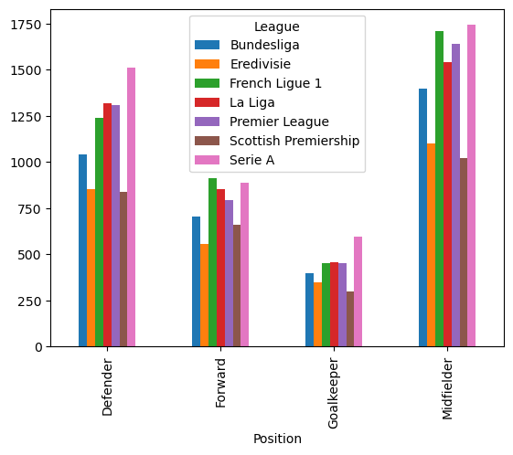

```python
playerStatsAllLeaguesNoTeamsContingencyTable.plot(kind='bar')
```

```python
check_cat_vs_cat_correlation(playerStatsAllLeaguesNoTeams, 'League', 'Position')
```

```
The odds of a correlation between League and Position is 99.99994389584538% (Based on a p value of 5.610415462071326e-07).
This percentage needs to be at least 95% for a significant correlation.
```

Thanks to this calculation it has become clear that there is a significant correlation between the leagues and the positions. This probably has a lot to do with the different play styles in the leagues.

In leagues like the Serie A it's very populair to play in a 1-5-3-2, a 1-3-5-2, and some teams even play in a 1-5-3-1-1 formation. These formations require only 1 or 2 attackers, and rely on a strong backline with fullbacks that have a lot of pace. While the midfielders must have a lot of technique to succesfully play in these formations. It is very logical for teams that play in these formation to not buy as much attackers as midfielders or defenders, because the attackers will simply get used less.

In some other leagues teams use a more offensive play style, like the French Ligue 1. In the bar plot can be seen that the Ligue 1 has a lot of attackers and (compared to the other leagues) has not a lot of defenders.

## Portfolio assignment 15

30 min: Train a decision tree to predict the species of a penguin based on their characteristics.

- Split the penguin dataset into a train (70%) and test (30%) set.
- Use the train set to fit a DecisionTreeClassifier. You are free to to choose which columns you want to use as feature variables and you are also free to choose the max_depth of the tree. **Note**: Some machine learning algorithms can not handle missing values. You will either need to
  - replace missing values (with the mean or most popular value). For replacing missing values you can use .fillna(\<value>) https://pandas.pydata.org/docs/reference/api/pandas.Series.fillna.html
  - remove rows with missing data. You can remove rows with missing data with .dropna() https://pandas.pydata.org/pandas-docs/stable/reference/api/pandas.DataFrame.dropna.html
- Use your decision tree model to make predictions for both the train and test set.
- Calculate the accuracy for both the train set predictions and test set predictions.
- Is the accurracy different? Did you expect this difference?
- Use the plot_tree_classification function above to create a plot of the decision tree. Take a few minutes to analyse the decision tree. Do you understand the tree?

Optional: Perform the same tasks but try to predict the sex of the pinguin based on the other columns

```python
from sklearn.model_selection import train_test_split
from sklearn.tree import DecisionTreeClassifier
from sklearn import tree
import graphviz
import pandas as pd
import seaborn as sns
import numpy as np
penguins = sns.load_dataset("penguins").dropna()
```

Split the penguin dataset into a train (70%) and test (30%) set.

```python
penguins_train, penguins_test = train_test_split(penguins, test_size=0.3, random_state=42, stratify=penguins['island'])
print(penguins_train.shape, penguins_test.shape)
```

```
(233, 7) (100, 7)
```

Use the train set to fit a DecisionTreeClassifier

```python
features = ['body_mass_g']
dt = DecisionTreeClassifier(max_depth = 2)
dt.fit(penguins_train[features], penguins_train['island'])
```

```
DecisionTreeClassifier(max_depth=2)
```

Create decision tree model

```python
def plot_tree_classification(model, features, class_names):
    dot_data = tree.export_graphviz(model,
                                    out_file=None,
                                    feature_names=features,
                                    class_names=class_names,
                                    filled=True,
                                    rounded=True,
                                    special_characters=True)
    graph = graphviz.Source(dot_data)
    graph.render("decision_tree")
    return graph
```

```python
plot_tree_classification(dt, features, np.sort(penguins_train.island.unique()))
```

[figure not shown]

Predict using the test array

```python
predictions = dt.predict(penguins_test[features])
predictions
```

```
array(['Biscoe', 'Dream', 'Dream', 'Dream', 'Dream', 'Dream', 'Dream',
       'Dream', 'Dream', 'Biscoe', 'Biscoe', 'Biscoe', 'Dream', 'Dream',
       'Dream', 'Dream', 'Biscoe', 'Biscoe', 'Biscoe', 'Dream', 'Dream',
       'Biscoe', 'Dream', 'Biscoe', 'Biscoe', 'Biscoe', 'Dream', 'Biscoe',
       'Biscoe', 'Dream', 'Dream', 'Biscoe', 'Biscoe', 'Biscoe', 'Dream',
       'Dream', 'Dream', 'Dream', 'Biscoe', 'Biscoe', 'Biscoe', 'Dream',
       'Dream', 'Biscoe', 'Dream', 'Biscoe', 'Dream', 'Biscoe', 'Dream',
       'Dream', 'Biscoe', 'Dream', 'Biscoe', 'Dream', 'Biscoe', 'Dream',
       'Biscoe', 'Biscoe', 'Dream', 'Biscoe', 'Biscoe', 'Dream', 'Biscoe',
       'Dream', 'Dream', 'Dream', 'Biscoe', 'Dream', 'Biscoe', 'Dream',
       'Dream', 'Dream', 'Dream', 'Dream', 'Dream', 'Dream', 'Dream',
       'Biscoe', 'Dream', 'Biscoe', 'Biscoe', 'Biscoe', 'Biscoe', 'Dream',
       'Dream', 'Dream', 'Biscoe', 'Biscoe', 'Biscoe', 'Dream', 'Dream',
       'Dream', 'Dream', 'Dream', 'Dream', 'Biscoe', 'Biscoe', 'Dream',
       'Biscoe', 'Biscoe'], dtype=object)
```

Calculating the accuracy of the tree

```python
def calculate_accuracy(predictions, actuals):
    if(len(predictions) != len(actuals)):
        raise Exception("The amount of predictions did not equal the amount of actuals")

    return (predictions == actuals).sum() / len(actuals)

predictionsOnTrainset = dt.predict(penguins_train[features])
predictionsOnTestset = dt.predict(penguins_test[features])

accuracyTrain = calculate_accuracy(predictionsOnTrainset, penguins_train.island)
accuracyTest = calculate_accuracy(predictionsOnTestset, penguins_test.island)

print("Accuracy on training set " + str(accuracyTrain))
print("Accuracy on test set " + str(accuracyTest))
```

```
Accuracy on training set 0.6738197424892703
Accuracy on test set 0.71
```

## Portfolio assignment 16

30 min: Train a decision tree to predict one of the categorical columns of your own dataset.

- Split your dataset into a train (70%) and test (30%) set.
- Use the train set to fit a DecisionTreeClassifier. You are free to to choose which columns you want to use as feature variables and you are also free to choose the max_depth of the tree.
- Use your decision tree model to make predictions for both the train and test set.
- Calculate the accuracy for both the train set predictions and test set predictions.
- Is the accurracy different? Did you expect this difference?
- Use the plot_tree function above to create a plot of the decision tree. Take a few minutes to analyse the decision tree. Do you understand the tree?

[figure not shown]

```python
import pandas as pd
import seaborn as sns
from sklearn.model_selection import train_test_split
from sklearn.tree import DecisionTreeClassifier
from sklearn import tree
import graphviz
import pandas as pd
import seaborn as sns
import numpy as np
type_dict = {'Team': 'object', 'Season': 'object', 'KEY': 'object', 'Player': 'object', 'Position': 'object', 'Appearances': 'float64', 'Goals': 'float64', 'Started': 'float64', 'Started As A Sub': 'float64', 'Came On': 'float64', 'Taken Off': 'float64', 'Own Goals': 'float64', 'Type Of Goal': 'object', 'First Half': 'float64', 'Second Half': 'float64', 'First Scorer': 'object', 'Last Scorer': 'object', 'Home': 'float64', 'Away': 'float64', 'Right Foot': 'float64', 'Left Foot': 'float64', 'Header': 'float64', 'Other Method': 'float64', 'Open Play': 'float64', 'Cross': 'float64', 'Free Kick': 'float64', 'Direct Free Kick': 'float64', 'Throw In': 'float64', 'Penalty': 'float64', 'Corner': 'float64', 'Other Type Of Play': 'float64', 'Minutes played': 'float64', 'Min/goal': 'float64', 'Assists': 'float64', '% Assists': 'float64', 'Leading Recipient': 'object', 'Recipient Goals': 'float64', 'CS': 'float64', '% Clean Sheets': 'float64', 'Hat Tricks': 'float64', 'Yellow Cards': 'float64', 'Yellow - First Half': 'float64', 'Yellow - Second Half': 'float64', 'Yellow - Home': 'float64', 'Yellow - Away': 'float64', 'Yelow - Minutes Played': 'float64', 'Minutes per Yellow Cards': 'float64', 'Sent Off': 'float64', 'Straight Red Card': 'float64', 'Two Yellow Cards': 'float64', 'Red - First Half': 'float64', 'Red - Second Half': 'float64', 'Red - Home': 'float64', 'Red - Away': 'float64', 'Red - Minutes Played': 'float64', 'Minutes per Red Cards': 'float64'}
playerStatsAllLeagues = pd.read_csv('merged-csv-files.csv', sep=',', dtype=type_dict)
playerStatsAllLeaguesNoTeams = playerStatsAllLeagues[(playerStatsAllLeagues['Position'] != 'Other') & (~playerStatsAllLeagues['Position'].isna())]
playerStatsAllLeaguesNoTeams
```

|  | League | Team | Season | KEY | Player | Position | Appearances | Goals | Started | Started As A Sub | ... | Minutes per Yellow Cards | Sent Off | Straight Red Card | Two Yellow Cards | Red First Half | Red Second Half | Red Home | Red Away | Red Minutes Played | Minutes per Red Cards |
| --- | --- | --- | --- | --- | --- | --- | --- | --- | --- | --- | --- | --- | --- | --- | --- | --- | --- | --- | --- | --- | --- |
| 1 | Premier League | Chelsea | 2014/15 | Premier League\|Chelsea\|2014/15 | Eden Hazard | Midfielder | 38.0 | 14.0 | 38.0 | 0.0 | ... | 1689.50 | NaN | NaN | NaN | NaN | NaN | NaN | NaN | NaN | NaN |
| 2 | Premier League | Chelsea | 2014/15 | Premier League\|Chelsea\|2014/15 | John Terry | Defender | 38.0 | 5.0 | 38.0 | 0.0 | ... | 1710.00 | NaN | NaN | NaN | NaN | NaN | NaN | NaN | NaN | NaN |
| 3 | Premier League | Chelsea | 2014/15 | Premier League\|Chelsea\|2014/15 | Branislav Ivanovic | Defender | 38.0 | 4.0 | 38.0 | 0.0 | ... | 310.91 | 1.0 | NaN | 1.0 | NaN | 1.0 | NaN | 1.0 | 3420.0 | 3420.0 |
| 4 | Premier League | Chelsea | 2014/15 | Premier League\|Chelsea\|2014/15 | Nemanja Matic | Midfielder | 36.0 | 1.0 | 35.0 | 1.0 | ... | 312.40 | 1.0 | 1.0 | NaN | NaN | 1.0 | 1.0 | NaN | 3164.0 | 3164.0 |
| 5 | Premier League | Chelsea | 2014/15 | Premier League\|Chelsea\|2014/15 | Gary Cahill | Defender | 36.0 | 1.0 | 33.0 | 5.0 | ... | 596.80 | NaN | NaN | NaN | NaN | NaN | NaN | NaN | NaN | NaN |
| ... | ... | ... | ... | ... | ... | ... | ... | ... | ... | ... | ... | ... | ... | ... | ... | ... | ... | ... | ... | ... | ... |
| 27915 | Scottish Premiership | Inverness Cali | 2016/17 | Scottish Premiership\|Inverness Cali\|2016/17 | Jason Brown | Midfielder | 0.0 | 0.0 | 0.0 | 3.0 | ... | NaN | NaN | NaN | NaN | NaN | NaN | NaN | NaN | NaN | NaN |
| 27916 | Scottish Premiership | Inverness Cali | 2016/17 | Scottish Premiership\|Inverness Cali\|2016/17 | Daniel Hoban | Goalkeeper | 0.0 | 0.0 | 0.0 | 10.0 | ... | NaN | NaN | NaN | NaN | NaN | NaN | NaN | NaN | NaN | NaN |
| 27917 | Scottish Premiership | Inverness Cali | 2016/17 | Scottish Premiership\|Inverness Cali\|2016/17 | Sam Robertson | Defender | 0.0 | 0.0 | 0.0 | 2.0 | ... | NaN | NaN | NaN | NaN | NaN | NaN | NaN | NaN | NaN | NaN |
| 27918 | Scottish Premiership | Inverness Cali | 2016/17 | Scottish Premiership\|Inverness Cali\|2016/17 | Andrew MacRae | Forward | 0.0 | 0.0 | 0.0 | 1.0 | ... | NaN | NaN | NaN | NaN | NaN | NaN | NaN | NaN | NaN | NaN |
| 27919 | Scottish Premiership | Inverness Cali | 2016/17 | Scottish Premiership\|Inverness Cali\|2016/17 | Blair MacLennan | Midfielder | 0.0 | 0.0 | 0.0 | 2.0 | ... | NaN | NaN | NaN | NaN | NaN | NaN | NaN | NaN | NaN | NaN |

26637 rows × 57 columns

#### Position & Goals

Split the dataset into a train (70%) and test (30%) set.

```python
playerStatsAllLeaguesNoTeams_train, playerStatsAllLeaguesNoTeams_test = train_test_split(playerStatsAllLeaguesNoTeams, test_size=0.3, random_state=42, stratify=playerStatsAllLeaguesNoTeams['Position'])
print(playerStatsAllLeaguesNoTeams_train.shape, playerStatsAllLeaguesNoTeams_test.shape)
```

```
(18645, 57) (7992, 57)
```

Use the train set to fit a DecisionTreeClassifier

```python
features = ['Goals']
dt = DecisionTreeClassifier(max_depth = 5)
dt.fit(playerStatsAllLeaguesNoTeams_train[features].fillna(0), playerStatsAllLeaguesNoTeams_train['Position'])
```

```
DecisionTreeClassifier(max_depth=5)
```

Create decision tree model

```python
def plot_tree_classification(model, features, class_names):
    dot_data = tree.export_graphviz(model,
                                    out_file=None,
                                    feature_names=features,
                                    class_names=class_names,
                                    filled=True,
                                    rounded=True,
                                    special_characters=True)
    graph = graphviz.Source(dot_data)
    graph.render("decision_tree")
    return graph
```

```python
plot_tree_classification(dt, features, np.sort(playerStatsAllLeaguesNoTeams_train['Position'].unique()))
```

[figure not shown]

Predict using the test array

```python
predictions_test = dt.predict(playerStatsAllLeaguesNoTeams_test[features])
predictions_test
```

```
array(['Midfielder', 'Midfielder', 'Defender', ..., 'Defender',
       'Midfielder', 'Defender'], dtype=object)
```

Calculating the accuracy of the tree

```python
def calculate_accuracy(predictions, actuals):
    if(len(predictions) != len(actuals)):
        raise Exception("The amount of predictions did not equal the amount of actuals")

    return (predictions == actuals).sum() / len(actuals)

predictionsOnTrainset = dt.predict(playerStatsAllLeaguesNoTeams_train[features])
predictionsOnTestset = dt.predict(playerStatsAllLeaguesNoTeams_test[features])

accuracyTrain = calculate_accuracy(predictionsOnTrainset, playerStatsAllLeaguesNoTeams_train['Position'])
accuracyTest = calculate_accuracy(predictionsOnTestset, playerStatsAllLeaguesNoTeams_test['Position'])

print("Accuracy on training set " + str(accuracyTrain))
print("Accuracy on test set " + str(accuracyTest))
```

```
Accuracy on training set 0.4079377849289354
Accuracy on test set 0.403028028028028
```

There is a very little difference between the accuracies of the sets, both are just really poor. because a lot of defenders and goalkeepers score no goals, the tree finds it hard to classify these positions. The program then chooses to completely ignore the goalkeeper position. Also there are a lot of attackers that score a few or even no goals. Using the amount of goals to predict the position did not turn out te be usefull.

## Portfolio assignment 17

30 min: Train a decision tree to predict the body_mass_g of a penguin based on their characteristics.

- Split the penguin dataset into a train (70%) and test (30%) set.
- Use the train set to fit a DecisionTreeRegressor. You are free to to choose which columns you want to use as feature variables and you are also free to choose the max_depth of the tree. **Note**: Some machine learning algorithms can not handle missing values. You will either need to
  - replace missing values (with the mean or most popular value). For replacing missing values you can use .fillna(\<value>) https://pandas.pydata.org/docs/reference/api/pandas.Series.fillna.html
  - remove rows with missing data. You can remove rows with missing data with .dropna() https://pandas.pydata.org/pandas-docs/stable/reference/api/pandas.DataFrame.dropna.html
- Use your decision tree model to make predictions for both the train and test set.
- Calculate the RMSE for both the train set predictions and test set predictions.
- Is the RMSE different? Did you expect this difference?
- Use the plot_tree_regression function above to create a plot of the decision tree. Take a few minutes to analyse the decision tree. Do you understand the tree?

```python
from sklearn.model_selection import train_test_split
from sklearn.tree import DecisionTreeClassifier
from sklearn import tree
import graphviz
import pandas as pd
import seaborn as sns
import numpy as np
from sklearn.tree import DecisionTreeRegressor
from sklearn import tree
import graphviz

penguins = sns.load_dataset("penguins").dropna()
def plot_tree_regression(model, features):
    # Generate plot data
    dot_data = tree.export_graphviz(model, out_file=None,
                          feature_names=features,
                          filled=True, rounded=True,
                          special_characters=True)

    # Turn into graph using graphviz
    graph = graphviz.Source(dot_data)

    # Write out a pdf
    graph.render("decision_tree")

    # Display in the notebook
    return graph

def calculate_rmse(predictions, actuals):
    if(len(predictions) != len(actuals)):
        raise Exception("The amount of predictions did not equal the amount of actuals")

    return (((predictions - actuals) ** 2).sum() / len(actuals)) ** (1/2)

penguins.dtypes
```

```
species               object
island                object
bill_length_mm       float64
bill_depth_mm        float64
flipper_length_mm    float64
body_mass_g          float64
sex                   object
dtype: object
```

Split the dataset into a train (70%) and test (30%) set.

```python
penguins_train, penguins_test = train_test_split(penguins, test_size=0.3, random_state=42, stratify=penguins['island'])
print(penguins_train.shape, penguins_test.shape)
```

```
(233, 7) (100, 7)
```

Fit decision tree regressor

```python
features= ['body_mass_g'] # add 'petal_width' ('species' does not work; categorical is not implemented in DT of sciki learn)
dt_regression = DecisionTreeRegressor(max_depth = 1) # Increase max_depth to see effect in the plot
dt_regression.fit(penguins_train[features], penguins_train['flipper_length_mm'])
```

```
DecisionTreeRegressor(max_depth=1)
```

Plot regression

```python
plot_tree_regression(dt_regression, features)
```

[figure not shown]

Evaluate

```python
predictionsOnTrainset = dt_regression.predict(penguins_train[features])
predictionsOnTestset = dt_regression.predict(penguins_test[features])

rmseTrain = calculate_rmse(predictionsOnTrainset, penguins_train['flipper_length_mm'])
rmseTest = calculate_rmse(predictionsOnTestset, penguins_test['flipper_length_mm'])

print("RMSE on training set " + str(rmseTrain))
print("RMSE on test set " + str(rmseTest))
```

```
RMSE on training set 7.936142779754285
RMSE on test set 10.42671864707595
```

## Portfolio assignment 18

30 min: Train a decision tree to predict one of the numerical columns of your own dataset.

- Split your dataset into a train (70%) and test (30%) set.
- Use the train set to fit a DecisionTreeRegressor. You are free to to choose which columns you want to use as feature variables and you are also free to choose the max_depth of the tree.
- Use your decision tree model to make predictions for both the train and test set.
- Calculate the RMSE for both the train set predictions and test set predictions.
- Is the accurracy different? Did you expect this difference?
- Use the plot_tree function above to create a plot of the decision tree. Take a few minutes to analyse the decision tree. Do you understand the tree?

[figure not shown]

```python
from sklearn.model_selection import train_test_split
from sklearn.tree import DecisionTreeClassifier
from sklearn import tree
import graphviz
import pandas as pd
import seaborn as sns
import numpy as np
from sklearn.tree import DecisionTreeRegressor
from sklearn import tree
import graphviz
type_dict = {'Team': 'object', 'Season': 'object', 'KEY': 'object', 'Player': 'object', 'Position': 'object', 'Appearances': 'float64', 'Goals': 'float64', 'Started': 'float64', 'Started As A Sub': 'float64', 'Came On': 'float64', 'Taken Off': 'float64', 'Own Goals': 'float64', 'Type Of Goal': 'object', 'First Half': 'float64', 'Second Half': 'float64', 'First Scorer': 'object', 'Last Scorer': 'object', 'Home': 'float64', 'Away': 'float64', 'Right Foot': 'float64', 'Left Foot': 'float64', 'Header': 'float64', 'Other Method': 'float64', 'Open Play': 'float64', 'Cross': 'float64', 'Free Kick': 'float64', 'Direct Free Kick': 'float64', 'Throw In': 'float64', 'Penalty': 'float64', 'Corner': 'float64', 'Other Type Of Play': 'float64', 'Minutes played': 'float64', 'Min/goal': 'float64', 'Assists': 'float64', '% Assists': 'float64', 'Leading Recipient': 'object', 'Recipient Goals': 'float64', 'CS': 'float64', '% Clean Sheets': 'float64', 'Hat Tricks': 'float64', 'Yellow Cards': 'float64', 'Yellow - First Half': 'float64', 'Yellow - Second Half': 'float64', 'Yellow - Home': 'float64', 'Yellow - Away': 'float64', 'Yelow - Minutes Played': 'float64', 'Minutes per Yellow Cards': 'float64', 'Sent Off': 'float64', 'Straight Red Card': 'float64', 'Two Yellow Cards': 'float64', 'Red - First Half': 'float64', 'Red - Second Half': 'float64', 'Red - Home': 'float64', 'Red - Away': 'float64', 'Red - Minutes Played': 'float64', 'Minutes per Red Cards': 'float64'}
playerStatsAllLeagues = pd.read_csv('merged-csv-files.csv', sep=',', dtype=type_dict)
playerStatsAllLeaguesNoTeams = playerStatsAllLeagues[(playerStatsAllLeagues['Position'] != 'Other') & (~playerStatsAllLeagues['Position'].isna())]
def plot_tree_regression(model, features):
    # Generate plot data
    dot_data = tree.export_graphviz(model, out_file=None,
                          feature_names=features,
                          filled=True, rounded=True,
                          special_characters=True)

    # Turn into graph using graphviz
    graph = graphviz.Source(dot_data)

    # Write out a pdf
    graph.render("decision_tree")

    # Display in the notebook
    return graph

def calculate_rmse(predictions, actuals):
    if(len(predictions) != len(actuals)):
        raise Exception("The amount of predictions did not equal the amount of actuals")

    return (((predictions - actuals) ** 2).sum() / len(actuals)) ** (1/2)

playerStatsAllLeaguesNoTeams
```

|  | League | Team | Season | KEY | Player | Position | Appearances | Goals | Started | Started As A Sub | ... | Minutes per Yellow Cards | Sent Off | Straight Red Card | Two Yellow Cards | Red First Half | Red Second Half | Red Home | Red Away | Red Minutes Played | Minutes per Red Cards |
| --- | --- | --- | --- | --- | --- | --- | --- | --- | --- | --- | --- | --- | --- | --- | --- | --- | --- | --- | --- | --- | --- |
| 1 | Premier League | Chelsea | 2014/15 | Premier League\|Chelsea\|2014/15 | Eden Hazard | Midfielder | 38.0 | 14.0 | 38.0 | 0.0 | ... | 1689.50 | NaN | NaN | NaN | NaN | NaN | NaN | NaN | NaN | NaN |
| 2 | Premier League | Chelsea | 2014/15 | Premier League\|Chelsea\|2014/15 | John Terry | Defender | 38.0 | 5.0 | 38.0 | 0.0 | ... | 1710.00 | NaN | NaN | NaN | NaN | NaN | NaN | NaN | NaN | NaN |
| 3 | Premier League | Chelsea | 2014/15 | Premier League\|Chelsea\|2014/15 | Branislav Ivanovic | Defender | 38.0 | 4.0 | 38.0 | 0.0 | ... | 310.91 | 1.0 | NaN | 1.0 | NaN | 1.0 | NaN | 1.0 | 3420.0 | 3420.0 |
| 4 | Premier League | Chelsea | 2014/15 | Premier League\|Chelsea\|2014/15 | Nemanja Matic | Midfielder | 36.0 | 1.0 | 35.0 | 1.0 | ... | 312.40 | 1.0 | 1.0 | NaN | NaN | 1.0 | 1.0 | NaN | 3164.0 | 3164.0 |
| 5 | Premier League | Chelsea | 2014/15 | Premier League\|Chelsea\|2014/15 | Gary Cahill | Defender | 36.0 | 1.0 | 33.0 | 5.0 | ... | 596.80 | NaN | NaN | NaN | NaN | NaN | NaN | NaN | NaN | NaN |
| ... | ... | ... | ... | ... | ... | ... | ... | ... | ... | ... | ... | ... | ... | ... | ... | ... | ... | ... | ... | ... | ... |
| 27915 | Scottish Premiership | Inverness Cali | 2016/17 | Scottish Premiership\|Inverness Cali\|2016/17 | Jason Brown | Midfielder | 0.0 | 0.0 | 0.0 | 3.0 | ... | NaN | NaN | NaN | NaN | NaN | NaN | NaN | NaN | NaN | NaN |
| 27916 | Scottish Premiership | Inverness Cali | 2016/17 | Scottish Premiership\|Inverness Cali\|2016/17 | Daniel Hoban | Goalkeeper | 0.0 | 0.0 | 0.0 | 10.0 | ... | NaN | NaN | NaN | NaN | NaN | NaN | NaN | NaN | NaN | NaN |
| 27917 | Scottish Premiership | Inverness Cali | 2016/17 | Scottish Premiership\|Inverness Cali\|2016/17 | Sam Robertson | Defender | 0.0 | 0.0 | 0.0 | 2.0 | ... | NaN | NaN | NaN | NaN | NaN | NaN | NaN | NaN | NaN | NaN |
| 27918 | Scottish Premiership | Inverness Cali | 2016/17 | Scottish Premiership\|Inverness Cali\|2016/17 | Andrew MacRae | Forward | 0.0 | 0.0 | 0.0 | 1.0 | ... | NaN | NaN | NaN | NaN | NaN | NaN | NaN | NaN | NaN | NaN |
| 27919 | Scottish Premiership | Inverness Cali | 2016/17 | Scottish Premiership\|Inverness Cali\|2016/17 | Blair MacLennan | Midfielder | 0.0 | 0.0 | 0.0 | 2.0 | ... | NaN | NaN | NaN | NaN | NaN | NaN | NaN | NaN | NaN | NaN |

26637 rows × 57 columns

Split the dataset into a train (70%) and test (30%) set.

```python
playerStatsAllLeaguesNoTeams_train, playerStatsAllLeaguesNoTeams_test = train_test_split(playerStatsAllLeaguesNoTeams, test_size=0.3, random_state=42, stratify=playerStatsAllLeaguesNoTeams['Position'])
print(playerStatsAllLeaguesNoTeams_train.shape, playerStatsAllLeaguesNoTeams_test.shape)
```

```
(18645, 57) (7992, 57)
```

Fit DecisionTreeRegressor

```python
features= ['Goals']
dt_regression = DecisionTreeRegressor(max_depth= 7)
dt_regression.fit(playerStatsAllLeaguesNoTeams_train[features], playerStatsAllLeaguesNoTeams_train['Appearances'])
```

```
DecisionTreeRegressor(max_depth=7)
```

Plot regressor

```python
plot_tree_regression(dt_regression, features)
```

[figure not shown]

Evaluate

```python
predictionsOnTrainset = dt_regression.predict(playerStatsAllLeaguesNoTeams_train[features])
predictionsOnTestset = dt_regression.predict(playerStatsAllLeaguesNoTeams_test[features])

rmseTrain = calculate_rmse(predictionsOnTrainset, playerStatsAllLeaguesNoTeams_train['Appearances'])
rmseTest = calculate_rmse(predictionsOnTestset, playerStatsAllLeaguesNoTeams_test['Appearances'])

print("RMSE on training set " + str(rmseTrain))
print("RMSE on test set " + str(rmseTest))
```

```
RMSE on training set 9.50661448915161
RMSE on test set 9.52044794953866
```

Although this outcome is logical. By finding out the perfect depth of the tree, I unconsciously prevented the tree from overfitting.

## Portfolio assignment 19

30 min: Create a cluster model on the penguins dataset.

- Use the pairplot() function on the penguins dataset. Do you visually notice any clusters? How many clusters do you think there are?
- Use the KMeans algorithm to create a cluster model. Apply this model to the dataset to create an extra column 'cluster' just like we did for the iris dataset above.  
  **Note**: Some machine learning algorithms can not handle missing values. You will either need to
  - replace missing values (with the mean or most popular value). For replacing missing values you can use .fillna(\<value>) https://pandas.pydata.org/docs/reference/api/pandas.Series.fillna.html
  - remove rows with missing data. You can remove rows with missing data with .dropna() https://pandas.pydata.org/pandas-docs/stable/reference/api/pandas.DataFrame.dropna.html
- Calculate the Silhouette Coefficient for your clustering. Play around with the features and n_clusters to search for better results. Keep the cluster model with the highest Silhouette Coefficient.
- Use the pairplot(hue='cluster') function to observe how the model has clustered the data.
- We know the species of each penguin. Use a contingency table to reveal the relation between the cluster results and the species. Is there an exact match? Are there species which ended up in the same cluster? If so, what does it mean that they ended up in the same cluster?

```python
import pandas as pd
import seaborn as sns
from sklearn.cluster import KMeans
import matplotlib.pyplot as plt
from sklearn import metrics
from sklearn.metrics import pairwise_distances
```

```python
penguins = sns.load_dataset("penguins")
penguins = penguins.dropna()
penguins.head()
```

|  | species | island | bill_length_mm | bill_depth_mm | flipper_length_mm | body_mass_g | sex |
| --- | --- | --- | --- | --- | --- | --- | --- |
| 0 | Adelie | Torgersen | 39.1 | 18.7 | 181.0 | 3750.0 | Male |
| 1 | Adelie | Torgersen | 39.5 | 17.4 | 186.0 | 3800.0 | Female |
| 2 | Adelie | Torgersen | 40.3 | 18.0 | 195.0 | 3250.0 | Female |
| 4 | Adelie | Torgersen | 36.7 | 19.3 | 193.0 | 3450.0 | Female |
| 5 | Adelie | Torgersen | 39.3 | 20.6 | 190.0 | 3650.0 | Male |

Use the pairplot() function on the penguins dataset. Do you visually notice any clusters? How many clusters do you think there are?

I expect 4 * 4 = 16 diagrams. For each numerical column one.

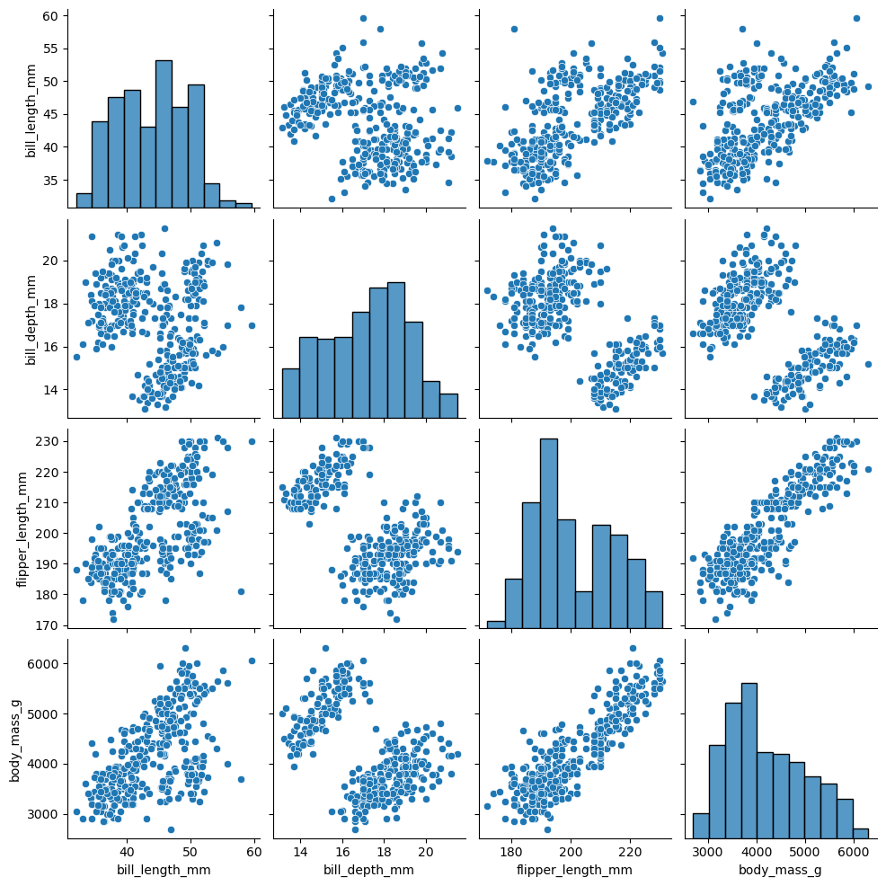

```python
sns.pairplot(penguins)
```

Use the KMeans algorithm to create a cluster model. Apply this model to the dataset to create an extra column 'cluster' just like we did for the iris dataset above.

```python
features = ['bill_length_mm','bill_depth_mm','flipper_length_mm', 'body_mass_g']
km = KMeans(n_clusters=2, random_state=43).fit(penguins[features])
```

```python
penguins['cluster'] = km.predict(penguins[features])
penguins
```

|  | species | island | bill_length_mm | bill_depth_mm | flipper_length_mm | body_mass_g | sex | cluster |
| --- | --- | --- | --- | --- | --- | --- | --- | --- |
| 0 | Adelie | Torgersen | 39.1 | 18.7 | 181.0 | 3750.0 | Male | 1 |
| 1 | Adelie | Torgersen | 39.5 | 17.4 | 186.0 | 3800.0 | Female | 1 |
| 2 | Adelie | Torgersen | 40.3 | 18.0 | 195.0 | 3250.0 | Female | 1 |
| 4 | Adelie | Torgersen | 36.7 | 19.3 | 193.0 | 3450.0 | Female | 1 |
| 5 | Adelie | Torgersen | 39.3 | 20.6 | 190.0 | 3650.0 | Male | 1 |
| ... | ... | ... | ... | ... | ... | ... | ... | ... |
| 338 | Gentoo | Biscoe | 47.2 | 13.7 | 214.0 | 4925.0 | Female | 0 |
| 340 | Gentoo | Biscoe | 46.8 | 14.3 | 215.0 | 4850.0 | Female | 0 |
| 341 | Gentoo | Biscoe | 50.4 | 15.7 | 222.0 | 5750.0 | Male | 0 |
| 342 | Gentoo | Biscoe | 45.2 | 14.8 | 212.0 | 5200.0 | Female | 0 |
| 343 | Gentoo | Biscoe | 49.9 | 16.1 | 213.0 | 5400.0 | Male | 0 |

333 rows × 8 columns

```python
penguins.cluster.value_counts()
```

```
1    203
0    130
Name: cluster, dtype: int64
```

```python
metrics.silhouette_score(penguins[features], km.labels_, metric='euclidean')
```

```
0.6307117469850305
```

Use the pairplot(hue='cluster') function to observe how the model has clustered the data.

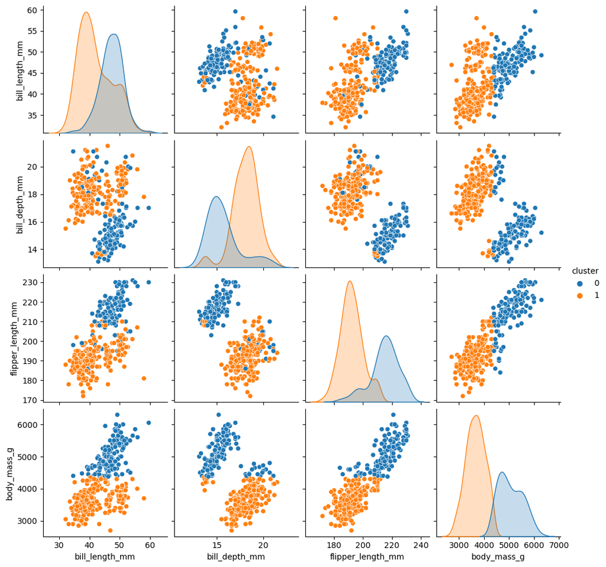

```python
sns.pairplot(penguins, hue="cluster")
plt.show()
```

We know the species of each penguin. Use a contingency table to reveal the relation between the cluster results and the species. Is there an exact match? Are there species which ended up in the same cluster? If so, what does it mean that they ended up in the same cluster?

```python
contingency_table = penguins.groupby(['species','cluster']).size().unstack('cluster', fill_value=0)
contingency_table
```

| cluster species | 0 | 1 |
| --- | --- | --- |
| Adelie | 14 | 132 |
| Chinstrap | 5 | 63 |
| Gentoo | 111 | 8 |

Two clustered are shown within the contingency table. Cluster 0 mainly contains the Gentoo species and the other two species can be found in the other cluster. From this cluster can be concluded that the species Adeilie and Chinstrap are very similar to eachother and that the Gentoo species differs from the rest.